# Pendeln in Deutschland

Zeit für die Bahn? – Eine datenbasierte Analyse

# Motivation

Jeden Morgen das gleiche Bild: Verstopfte Autobahnen, genervte Pendler, verlorene Zeit. **20,5 Millionen Menschen** pendeln in Deutschland täglich zur Arbeit – die meisten davon mit dem Auto. Laut [INRIX Traffic Scorecard 2024](https://inrix.com/scorecard/) verlieren Pendler in deutschen Großstädten zwischen 40 und 60 Stunden pro Jahr allein im Stau. Das entspricht fast einer kompletten Arbeitswoche, die im Nichts verpufft.

Die Idee liegt auf der Hand: **Wer Bahn fährt, steht nicht im Stau.** Aber wie schlägt sich die Bahn im Vergleich zum Auto? Ist sie wirklich schneller? Und wie zuverlässig ist sie eigentlich?

In diesem Projekt analysieren Sie **Echtzeitdaten der Deutschen Bahn**, **Pendlerstatistiken der Bundesagentur für Arbeit**, **Staudaten von INRIX** und die **Entgeltstatistik der Bundesagentur für Arbeit**. Sie werden herausfinden, dass die Antwort auf die Frage “Sollten mehr Menschen Bahn fahren?” komplexer ist, als man zunächst vermuten würde und dass sie wichtige Implikationen für die Verkehrspolitik hat.

Ihre zentrale Forschungsfrage lautet:

> **“Sollten mehr Menschen Bahn fahren – und was müsste sich dafür ändern?”**

# Datengrundlage

In diesem Projekt arbeiten Sie mit mehreren Datensätzen. Ein wichtiger Teil des Projekts ist das **eigenständige Beschaffen von Primärdaten** aus offiziellen Quellen.

## Daten einlesen und verstehen

Bevor Sie mit der Analyse beginnen können, müssen Sie verschiedenste Datensätze einlesen und deren Struktur verstehen. Die Deutsche Bahn stellt über unterschiedliche Schnittstellen Echtzeitdaten für ihre Züge als open-source Daten zur Verfügung, welche per API-Calls geladen werden können. Jedoch gibt es von der Deutschen Bahn keine offizielle Seite, welche historische Daten zu Zugverspätungen, Ausfällen etc. für Fern- und Nahverkehrszüge sammelt. Da wir uns jedoch mit historischen Daten beschäftigen möchten, greifen wir auf Daten zurück, die von [Piet Brömmel](https://github.com/piebro/deutsche-bahn-data) gesammelt wurden und bei Huggingface im **Parquet-Format** zur Verfügung gestellt wurden. Das **Parquet-Format** ist ein effizientes Datenformat und wird oft für große Datenmengen genutzt; in R können Sie diese Daten mit dem `arrow`-Paket einlesen.

1. **Wie pünktlich ist die Bahn wirklich?** Um diese Frage zu beantworten, brauchen Sie echte Verspätungsdaten – nicht nur Pressemitteilungen. Die Bahndaten bilden das **Herzstück unserer Analyse**: Mit ihnen können Sie berechnen, wie viel Zeit Bahnfahrer durch Verspätungen verlieren und später mit den Stauzeiten der Autofahrer vergleichen.

Die Deutsche Bahn stellt Echtzeitdaten als Open Data zur Verfügung. Das Projekt piebro/deutsche-bahn-data auf Huggingface sammelt diese Daten im Parquet-Format.

Laden Sie die Datei für **November 2025** direkt von Huggingface herunter und lesen Sie diesen Datensatz als `bahn` in R ein.

Zeigen Sie die ersten 10 Zeilen des Datensatzes in einer Tabelle und beantworten Sie anschließend folgende Fragen:

- Wie viele Beobachtungen enthält der Datensatz? Welche Variablen sind vorhanden?
- Was stellt eine einzelne Beobachtung dar?

*Hinweis 1:* Sie können auf Huggingface die gesuchte Datei [hier](https://huggingface.co/datasets/piebro/deutsche-bahn-data/resolve/main/monthly_processed_data/data-2025-11.parquet) finden und direkt die URL zu der Datei in R mitgeben

*Hinweis 2:* Sie können die Parquet Datei entweder lokal speichern, oder immer direkt per URL einlesen. Falls Sie die Datei lokal speichern, so wird diese nicht auf GitHub Committet, da wir dies in der .gitignore entsprechend eingestellt haben. In diesem Fall sollten alle Teammitglieder die Datei lokal zur Verfügung haben.

*Hinweis 3:* Achten Sie bei allen Tabellen auf einer saubere Darstellung

**Erste 10 Zeilen des Bahndatensatzes (November 2025)**

| station_name | final_destination_station | delay_in_min | is_canceled | train_type |
| --- | --- | --- | --- | --- |
| Stuttgart Hbf | Filderstadt | 5 | FALSE | S |
| Halle (Saale) Hbf | Leipzig Hbf (tief) | 1 | FALSE | S |
| Karlsruhe Hbf | Karlsruhe Hbf | 95 | FALSE | RE |
| Regensburg Hbf | München Hbf | 11 | FALSE | ALX |
| Mannheim Hbf | Karlsruhe Hbf | 1 | FALSE | ICE |
| Flughafen BER | Flughafen BER | 1 | FALSE | S |
| Halle (Saale) Hbf | Halle (Saale) Hbf | 15 | FALSE | S |
| München Hbf | München Hbf | 0 | FALSE | RB |
| Köln Hbf | Köln Hbf | 40 | FALSE | IC |
| Freiburg (Breisgau) Hbf | Freiburg (Breisgau) Hbf | 0 | FALSE | S |

**Anzahl der Beobachtungen und Art der Variablen**

Der Datensatz enthält insgesamt 13.943.561 Beobachtungen und umfasst 16 Variablen. Zu den Variablen gehören unter anderem der Name des Bahnhofs (station_name), alternative Stationsbezeichnungen (xml_station_name), eine eindeutige Stationskennung (eva), Angaben zum Zug wie Zugname, Zugtyp und Linie, das geplante und tatsächliche Ankunfts- und Abfahrtsdatum, die Verspätung in Minuten (delay_in_min), Informationen über Zugausfälle (is_canceled) sowie eine eindeutige ID für jede Beobachtung.

**Was stellt eine einzelne Beobachtung dar?**

Eine einzelne Beobachtung beschreibt ein konkretes Zugereignis an einem bestimmten Bahnhof zu einem bestimmten Zeitpunkt. Sie enthält Informationen darüber, welcher Zug an welcher Station geplant war, ob und wie stark er verspätet war, ob es zu Änderungen bei Ankunft oder Abfahrt kam und ob der Zug eventuell ausgefallen ist. Der Datensatz bildet damit sehr detailliert den tatsächlichen Betriebsablauf des Bahnverkehrs im November 2025 ab.

2. **Wohin pendeln die Menschen?** Die Bahndaten zeigen ihnen die Pünktlichkeit der Züge – aber um zu verstehen, wo gute Bahnverbindungen besonders wichtig sind, müssen Sie wissen, **wohin die Menschen pendeln**. Die Pendlerstatistik der Bundesagentur für Arbeit zeigt genau das: Welche Städte sind die größten Arbeitgeber-Magneten?

Laden Sie den Datensatz `pendler_kreise_aufbereitet.csv` aus dem Ordner `daten` in R ein als Datensatz `pendler`.

Erstellen Sie eine Tabelle der **Top 10 Städte** nach Einpendlern mit den Spalten: Stadt (kreis_name), Einpendler, Auspendler, Pendlersaldo.

Interpretieren Sie kurz: Welche Städte sind die größten “Pendlermagneten” Deutschlands und warum?

**Top 10 Städte nach Einpendlern**

| Stadt | Einpendler | Auspendler | Pendlersaldo |
| --- | --- | --- | --- |
| München, Landeshauptstadt | 455.645 | 202.756 | 252.889 |
| Frankfurt am Main, Stadt | 405.856 | 111.245 | 294.611 |
| Hamburg, Freie und Hansestadt | 392.951 | 147.328 | 245.623 |
| Berlin, Stadt | 392.324 | 219.898 | 172.426 |
| Köln, Stadt | 306.905 | 138.422 | 168.483 |
| Düsseldorf, Stadt | 284.696 | 97.326 | 187.370 |
| Stuttgart, Landeshauptstadt | 274.442 | 100.095 | 174.347 |
| Nürnberg, Stadt | 165.496 | 78.557 | 86.939 |
| Essen, Stadt | 141.296 | 90.906 | 50.390 |
| Region Hannover | 137.924 | 69.974 | 67.950 |

**Einordnung der Tabelle**

Die Tabelle zeigt die zehn Städte in Deutschland mit den meisten Einpendlern. Für jede Stadt sind die Anzahl der Einpendler, der Auspendler sowie der Pendlersaldo angegeben. Der Pendlersaldo ergibt sich aus der Differenz zwischen Einpendlern und Auspendlern und zeigt, ob eine Stadt mehr Arbeitsplätze bietet, als dort wohnende Personen auspendeln.

**Größte Pendlermagneten und Ursachen**

München, Frankfurt am Main, Hamburg und Berlin gehören zu den größten Pendlermagneten Deutschlands. Sie weisen sowohl sehr hohe Einpendlerzahlen als auch deutlich positive Pendlersalden auf. Diese Städte sind wirtschaftlich besonders stark, zählen zu den größten Städten Deutschlands und bieten viele Arbeitsplätze in zentralen Branchen wie Industrie, Dienstleistungen, Verwaltung und Finanzwesen. Zusätzlich sind sie wichtige Hochschulstandorte, etwa München mit der Technischen Universität München und der Ludwig-Maximilians-Universität. Gleichzeitig sind die Lebenshaltungskosten, insbesondere die Mieten, in diesen Städten sehr hoch, weshalb viele Beschäftigte im Umland wohnen und täglich in die Stadt pendeln.

3. **Was kostet das Auto?** Sie haben jetzt Bahndaten und wissen, wohin die Menschen pendeln. Aber um fair vergleichen zu können, brauchen Sie auch die **Alternative**: Wie viel Zeit verlieren Autofahrer im Stau? Diese Daten liefert INRIX – ein Unternehmen, das weltweit Verkehrsdaten sammelt. Später werden Sie diese Staukosten mit den Bahnverspätungen vergleichen.

Besuchen Sie die [INRIX Global Traffic Scorecard](https://inrix.com/scorecard/) und suchen Sie die Stauzeiten für die Top 10 Städte aus Aufgabe 2 und zusätzlich die Stauzeiten für Ulm. INRIX misst, wie viele Stunden Autofahrer jährlich im Stau verlieren.

- Erstellen Sie eine eigene CSV-Datei `inrix_staedte_2024.csv` mit folgenden Spalten für die geforderten Städte:
  - `stadt`: Name der Stadt
  - `stau_stunden_jahr`: Jährliche Staustunden pro Fahrer
  - `kosten_eur`: Jährliche Kosten pro Fahrer (findet sich in der tiefergehenden Übersicht)
- Berechnen Sie für jede Stadt, wie viele **Arbeitstage pro Jahr** im Stau verloren gehen. Annahme: Ein Arbeitstag = 8 Stunden.

Erstellen Sie anschließend eine schöne Tabelle mit: Stadt, Staustunden/Jahr, verlorene Arbeitstage und beschreiben diese. In welcher Stadt ist die Stausituation am schlimmsten? Wie viele Arbeitstage verliert ein typischer Pendler dort pro Jahr?

*Hinweis:* Auf der INRIX-Website können Sie nach bei “Jump to City Rankings” -> “Search the List” -> “Germany” oder der konkreten Stadt filtern.

**INRIX: Jährliche Staubelastung pro Fahrer**

| Stadt | Staustunden | Verlorene Arbeitstage (8h) | Kosten pro Fahrer (€) |
| --- | --- | --- | --- |
| Köln | 67 | 8,38 | 919 |
| Düsseldorf | 63 | 7,88 | 864 |
| Berlin | 60 | 7,50 | 823 |
| Stuttgart | 60 | 7,50 | 823 |
| München | 57 | 7,12 | 781 |
| Frankfurt | 55 | 6,88 | 754 |
| Hannover | 54 | 6,75 | 740 |
| Hamburg | 46 | 5,75 | 631 |
| Essen | 46 | 5,75 | 631 |
| Nürnberg | 38 | 4,75 | 521 |
| Ulm | 30 | 3,75 | 411 |

**Beschreibung der Tabelle**

Man kann dabei sehen, dass die Staustunden am höchsten in Köln mit 67 Stunden pro Jahr und Fahrer liegen. Die Städte Düsseldorf, Berlin, Stuttgart und München befinden sich ebenfalls in einem Wertebereich nahe der 60 Stunden. Die Stunden sinken mit absteigender Reihenfolge und Ulm bildet das Schlusslicht mit 30 Staustunden. Da die anderen beiden Variablen direkt mit der ersten zusammenhängen, gleicht das Bild der Verteilung dem aus der ersten Variable. Dabei haben Kölner Fahrer im Jahr 8,38 verlorene Vollzeit-Arbeitstage und damit einhergehend auch die höchsten Kosten. Dem anschließend folgt die gleiche Reihenfolge, wie bei den Staustunden. Frankfurt im Mittelfeld verzeichnet dabei 6,88 verlorene Arbeitstage mit Kosten von 754 € pro Fahrer. Auch hier bildet Ulm das Schlusslicht mit 3,75 verlorenen Arbeitstagen und Kosten in Höhe von 411 € pro Fahrer.

**Interpretation der Ergebnisse**

Man kann sehen, dass es nicht eine Stadt in Deutschland gibt, die bei der Staubelastung drastisch heraussticht. Die Unterschiede sind vorhanden, jedoch zeigt sich hier der Fakt, dass es in Deutschland keine Stadt mit einer massiv überproportionalen Bevölkerungsdichte im Vergleich zum Rest des Landes gibt (hier als Vergleich z. B. Tokio mit der Hälfte der gesamten Bevölkerung eines Landes in einer Stadt). Dennoch sehen wir gerade in den größten Städten auch die höchsten Staustunden und damit die höchsten Kosten. Ein genauer Zusammenhang wird allerdings erst später analysiert und kann aktuell noch nicht hergestellt werden.

Mit bis zu acht verlorenen Arbeitstagen kann man dennoch sagen, dass sehr viel Zeit und damit auch Produktivität eingebüßt wird. Nach OECD-Daten zur Arbeitsproduktivität lag der Wert für Deutschland 2023 bei etwa 82,96 USD pro Arbeitsstunde (gemessen als Bruttoinlandsprodukt je Arbeitsstunde in Kaufkraftparitäten), was eine beträchtliche wirtschaftliche Relevanz darstellt (Our World in Data 2025). Ein Wert, der schwer wiegt, wenn man ihn mit dem Zeitverlust durch Staus verknüpft und anschließend auf die Summe aller Fahrer herunterbricht. Zudem entstehen in den großen Städten auch Kosten pro Fahrer, die vom Betrag nicht unterschätzt werden sollten. Alles in allem gibt die Tabelle eine erste kurze Übersicht zum aktuellen Stand der Staubelastung und lässt schließen, dass jene Belastung auch wirtschaftliche Schäden mit sich trägt, welche nun weiter ermittelt und ausgearbeitet werden.

4. Für die weiteren Analysen stellen wir Ihnen **fünf zusätzliche Datensätze** bereit. Diese laden Sie jetzt, damit sie in allen folgenden Aufgaben direkt verfügbar sind.

Laden Sie die folgenden Datensätze aus dem Ordner `daten` und speichern Sie diese unter den angegebenen Variablennamen:

| Datei | Variablenname | Verwendet in |
| --- | --- | --- |
| `bahnhof_ags_mapping.csv` | `bahnhof_mapping` | Aufgabe 9-10 |
| `fahrtzeit_osrm_vergleich.csv` | `fahrtzeit` | Aufgabe 12 |
| `ulm_pendlerrouten.csv` | `ulm_routen` | Aufgabe 13 |
| `ba_entgeltstatistik_2024.csv` | `entgelt` | für `staedte_basis` |
| `co2_analyse.csv` | `co2_analyse` | Aufgabe 19 (Bonus) |

Verschaffen Sie sich einen ersten Überblick über die Struktur der Daten (z.B. mit `glimpse()`, dies sollte später in ihrem HTML Dokument nicht sichtbar sein!).

**Erstellen Sie außerdem einen Master-Datensatz** `staedte_basis` für die Top-11-Städte (Top 10 Pendlerstädte + Ulm), der die Daten aus `pendler`, `entgelt` und `inrix` kombiniert. Dieser Datensatz vereinfacht die späteren Analysen (ab Aufgabe 14), da alle relevanten Kennzahlen bereits zusammengeführt sind.

Der Master-Datensatz sollte folgende Spalten enthalten:

- `ags`: Amtlicher Gemeindeschlüssel
- `stadt`: Stadtname (Kurzform, z.B. “München”)
- `einpendler`: Anzahl Einpendler
- `median_monat_eur`: Medianlohn pro Monat
- `median_stunde_eur`: Medianlohn pro Stunde (Monatslohn / 160)
- `stau_stunden_jahr`: Stauzeit pro Jahr (aus INRIX)

*Hinweis 1:* Die Datensätze verwenden unterschiedliche Namensformate: `pendler` hat offizielle Namen (“München, Landeshauptstadt”), während `entgelt` und `inrix` Kurznamen (“München”) verwenden. Nutzen Sie den **AGS** als zuverlässigen Schlüssel für die Verknüpfung mit `pendler`. Tipp: `entgelt` enthält sowohl AGS als auch Kurznamen und eignet sich daher gut als Ausgangspunkt.

*Hinweis 2:* Eine ausführliche Beschreibung der Datensätze finden Sie im **Anhang A**.

# Die Pünktlichkeit der Deutschen Bahn

Nachdem Sie nun einen Überblick über die Daten haben, welche wir in diesem Projekt verwenden möchten, tauchen Sie tiefer in die Bahndaten ein. Die zentrale Frage ist: **Wie zuverlässig ist die Deutsche Bahn wirklich?**

Die Bahn unterscheidet verschiedene Zugtypen, vom ICE über den RE bis zur S-Bahn. Jeder Zugtyp hat unterschiedliche Eigenschaften: Der ICE fährt lange Strecken mit wenigen Halten, die S-Bahn kurze Strecken mit vielen Halten. Aber welcher Zugtyp ist am pünktlichsten?

5. **Welche Züge sind (un)pünktlich?** Nicht alle Züge sind gleich: Der ICE fährt lange Strecken mit wenigen Halten, die S-Bahn kurze Strecken mit vielen Halten. Um später sinnvolle Empfehlungen geben zu können, müssen Sie verstehen, **welche Zugtypen besonders problematisch sind**. Dafür klassifizieren Sie die Züge anhand ihrer Namen. Nutzen Sie für diese Analyse den Datensatz `bahn`.

Die Variable `train_name` enthält den Zugnamen (z.B. “ICE 123”, “S 5”, “RE 8”).

- Erstellen Sie eine neue Variable `zugtyp` mit folgenden Kategorien:

| Zugtyp | Regel | Beispiel |
| --- | --- | --- |
| ICE | beginnt mit “ICE” | ICE 123 |
| IC/EC | beginnt mit “IC” oder “EC” | IC 2012, EC 6 |
| IRE/RE | beginnt mit “RE” oder “IRE” | RE 5, IRE 200 |
| RB | beginnt mit “RB” | RB 26 |
| S-Bahn | beginnt mit “S” (mit Leerzeichen!) | S 5 |
| Sonstige | alle anderen | U 6, STB 123 |

Erstellen Sie auf dieser Basis eine Tabelle, welche pro Zugtyp folgende Kennzahlen anschaulich darstellt:

- Anzahl der Fahrten
- Durchschnittliche Verspätung (in Minuten)
- Anteil pünktlicher Züge (≤6 Min Verspätung)
- Ausfallquote

Beschreiben und Interpretieren Sie die Tabelle.

Weiterhin sollten Sie ihre Ergebnisse verifizieren. Dafür können Sie auf die offizielle Pünktlichkeitswerte der Deutschen Bahn zurückgreifen (recherchieren Sie diese selbstständig).

Stimmen Ihre Ergebnisse mit den offiziellen Werten überein? Falls nicht: Welche methodischen Unterschiede könnten die Abweichung erklären?

*Hinweis:* Nutzen Sie `str_detect()` aus dem `stringr`-Paket. Achten Sie auf die Reihenfolge der Bedingungen!

**Pünktlichkeit nach Zugtyp (November 2025)**

| Zugtyp | Fahrten | Ø Verspätung (min) | Anteil pünktlich (%) | Ausfallquote (%) |
| --- | --- | --- | --- | --- |
| IC/EC | 70.602 | 11,0 | 60,2 | 7,2 |
| ICE | 171.516 | 12,5 | 56,7 | 4,2 |
| IRE/RE | 1.673.555 | 6,1 | 74,1 | 3,6 |
| RB | 2.675.028 | 3,5 | 85,2 | 3,2 |
| S-Bahn | 6.414.045 | 2,9 | 87,4 | 5,5 |
| Sonstige | 2.938.815 | 3,5 | 84,7 | 2,6 |

**Beschreibung der Tabelle**

Bei der durchschnittlichen Verspätung zeigen sich klare Unterschiede zwischen den Zugtypen. ICE Züge weisen mit durchschnittlich 12,5 Minuten die höchsten Verspätungen auf, gefolgt von IC/EC mit 11,0 Minuten. Im Nahverkehr liegen die durchschnittlichen Verspätungen deutlich niedriger: IRE/RE bei 6,1 Minuten, RB bei 3,5 Minuten und S-Bahn bei 2,9 Minuten. Entsprechend ist der Anteil pünktlicher Fahrten im Nahverkehr höher. Die S-Bahn erreicht mit 87,4 Prozent den höchsten Wert, gefolgt von RB (85,2 Prozent). ICE und IC/EC erreichen dagegen nur 56,7 Prozent bzw. 60,2 Prozent pünktliche Fahrten. Die Ausfallquote variiert zwischen 2,6 Prozent bei Sonstigen und 7,2 Prozent bei IC/EC, wobei auch die S-Bahn mit 5,5 Prozent eine vergleichsweise erhöhte Ausfallquote aufweist.

**Interpretation der Ergebnisse**

Die Tabelle verdeutlicht strukturelle Unterschiede zwischen Fern- und Nahverkehr. Fernverkehrszüge wie ICE und IC/EC sind im Durchschnitt deutlich unpünktlicher. Dies lässt sich unter anderem durch die langen Strecken, die hohe Netzabhängigkeit und die komplexe Einbindung in den gesamten Bahnverkehr erklären. Verspätungen können sich hier über große Distanzen fortsetzen und verstärken.

Der Nahverkehr schneidet insgesamt deutlich besser ab. Besonders die S-Bahn weist trotz kurzer Strecken mit vielen Halten sehr geringe durchschnittliche Verspätungen und einen hohen Anteil pünktlicher Fahrten auf. Dies deutet auf eine grundsätzlich stabile Betriebsführung hin. Gleichzeitig ist die Ausfallquote der S-Bahn vergleichsweise hoch, was darauf schließen lässt, dass bei Störungen eher einzelne Fahrten gestrichen werden, um den restlichen Betrieb aufrechtzuerhalten. RB- und IRE/RE Züge liegen in ihren Werten zwischen S-Bahn und Fernverkehr. Sie profitieren von regional begrenzten Einsatzgebieten, sind jedoch stärker von Mischverkehr mit Fernzügen abhängig, was sich in etwas höheren Verspätungen widerspiegelt.

**Vergleich mit offiziellen Pünktlichkeitswerten der Deutschen Bahn**

Die in dieser ausgewertete Tabelle „Pünktlichkeit nach Zugtyp (November 2025)” basiert auf dem Datensatz `bahn` und umfasst ausschließlich Zugfahrten aus dem November 2025. Laut Deutscher Bahn lag im November 2025 die betriebliche Pünktlichkeit im Personenverkehr bei 84,5 %, im Fernverkehr bei 54,5 % und im Nahverkehr bei 85,2 %. Die Reisendenpünktlichkeit im Fernverkehr betrug 61,9 (Deutsche Bahn 2025).

Die eigenen Ergebnisse liegen nahe an diesen Referenzwerten. Für den Fernverkehr zeigen sich leicht höhere Pünktlichkeitsanteile (ICE: 56,7 %, IC/EC: 60,2 %), während die Werte im Nahverkehr (RB: 85,2 %, S-Bahn: 87,4 %) sehr gut mit den offiziellen Angaben übereinstimmen. Damit bestätigen die eigenen Auswertungen das bekannte Muster einer deutlich geringeren Pünktlichkeit im Fernverkehr gegenüber dem Nahverkehr.

Kleinere Abweichungen lassen sich vor allem durch methodische Unterschiede erklären. In den offiziellen Statistiken gilt ein Zug als pünktlich, wenn er mit weniger als 5 Minuten und 59 Sekunden Verspätung ankommt, während in dieser Analyse auch Fahrten mit bis einschließlich 6 Minuten Verspätung als pünktlich gezählt wurden. Darüber hinaus unterscheiden sich betriebliche Pünktlichkeit und Reisendenpünktlichkeit hinsichtlich der zugrunde liegenden Definitionen. Geringfügige Abweichungen können zudem dadurch entstehen, dass Werte unterschiedlich gerundet werden oder Ausfälle nicht identisch klassifiziert sind. Darüber hinaus spielen Unterschiede in der zeitlichen und räumlichen Abdeckung der Daten sowie vereinzelt vorhandene Ungenauigkeiten im Datensatz eine Rolle.

6. In Aufgabe 5 haben Sie gesehen, dass Fernverkehrszüge (ICE, IC/EC) deutlich höhere Verspätungen und Ausfallquoten haben als Nahverkehrszüge (IRE, RE, RB, S-Bahn). Aber wie relevant ist das für den typischen Pendler? Das hängt davon ab, **wie viele Züge** jeweils unterwegs sind. Nutzen Sie für diese Analyse den Datensatz `bahn` (mit der in Aufgabe 5 erstellten Variable `zugtyp`).

Klassifizieren Sie die Züge in zwei Kategorien:

- **Fernverkehr**: ICE, IC/EC
- **Nahverkehr**: IRE, RE, RB, S-Bahn

Erstellen Sie ein **Liniendiagramm**, das die **durchschnittliche Anzahl der Fahrten pro Stunde** im Tagesverlauf zeigt:

- X-Achse: Uhrzeit (0-23 Uhr)
- Y-Achse: Durchschnittliche Anzahl Fahrten pro Stunde
- Zwei Linien: eine für Fernverkehr, eine für Nahverkehr (unterschiedliche Farben)

*Tipp:* Extrahieren Sie die Stunde aus der Variable `time` mit `hour()` aus dem `lubridate`-Paket. Berechnen Sie dann die durchschnittliche Anzahl Fahrten pro Stunde und Zugtyp.

Beschreiben und interpretieren Sie ihre Grafik. Beantworten Sie zusätzlich die folgenden Fragen:

- Zu welchen Uhrzeiten fahren die meisten Züge?
- Wie unterscheidet sich das Muster zwischen Fern- und Nahverkehr?
- Warum ist diese Information wichtig, wenn wir später die Verspätungen analysieren?

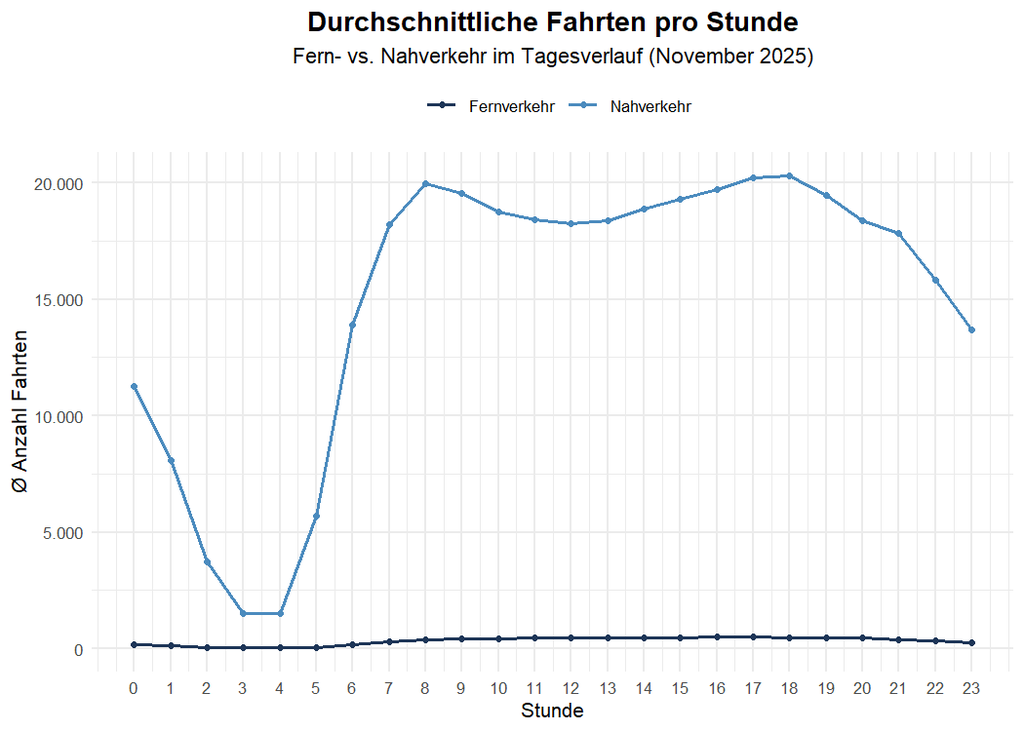

**Beschreibung der Grafik**

Die Grafik zeigt den durchschnittlichen stündlichen Umfang geplanter Zugfahrten im Fern- und Nahverkehr über einen gesamten Tag. Auf der x-Achse sind die Stunden von 0 bis 23 Uhr dargestellt, auf der y-Achse die durchschnittliche Anzahl der Fahrten pro Stunde. Der Nahverkehr dominiert das Bild deutlich: In nahezu allen Stunden ist die Anzahl der Fahrten um ein Vielfaches höher als im Fernverkehr. In den frühen Nachtstunden zwischen etwa 2 und 4 Uhr erreicht der Nahverkehr sein Minimum, während ab den frühen Morgenstunden ein starker Anstieg zu beobachten ist. Ab etwa 7 Uhr morgens bleibt das Niveau hoch und relativ stabil bis in die frühen Abendstunden, bevor es ab etwa 20 Uhr wieder merklich abnimmt. Der Fernverkehr weist insgesamt deutlich geringere Fahrtenzahlen auf. Auch hier ist nachts ein niedriger Wert zu erkennen, mit einem moderaten Anstieg ab den Morgenstunden und einem leichten Höhepunkt am späten Vormittag bzw. frühen Nachmittag. Die Schwankungen sind im Vergleich zum Nahverkehr weniger ausgeprägt.

**Interpretation der Ergebnisse**

Die Grafik verdeutlicht typische tageszeitliche Nutzungsmuster des Bahnverkehrs. Die höchsten Fahrtenzahlen treten im Nahverkehr tagsüber auf, insbesondere zwischen dem frühen Morgen und dem frühen Abend. Dieses Muster spiegelt den Berufs- und Pendlerverkehr wider, da der Nahverkehr vor allem für Arbeits-, Ausbildungs- und Alltagswege genutzt wird. Die sehr niedrigen Werte in den Nachtstunden lassen sich durch eingeschränkte Fahrpläne und geringere Nachfrage erklären. Der Fernverkehr zeigt ein deutlich flacheres Tagesprofil. Zwar nimmt auch hier die Anzahl der Fahrten tagsüber zu, jedoch fallen die Spitzen weniger stark aus. Dies deutet darauf hin, dass Fernverkehrszüge stärker an feste Taktungen gebunden sind und weniger auf kurzfristige Nachfragespitzen reagieren als der Nahverkehr.

**Zu welchen Uhrzeiten fahren die meisten Züge?**

Die meisten Züge fahren im Nahverkehr zwischen etwa 7 Uhr morgens und 19 Uhr abends, mit besonders hohen Werten am Morgen und am späten Nachmittag. Im Fernverkehr liegt das Maximum ebenfalls tagsüber, jedoch weniger ausgeprägt und auf einem deutlich niedrigeren Niveau.

**Wie unterscheidet sich das Muster zwischen Fern- und Nahverkehr?**

Der Nahverkehr zeigt starke tageszeitliche Schwankungen mit klaren Höhepunkten am Tag und sehr niedrigen Werten in der Nacht. Der Fernverkehr weist dagegen ein relativ gleichmäßiges Muster mit geringeren Ausschlägen auf. Zudem ist die absolute Anzahl der Fahrten im Nahverkehr in allen Stunden deutlich höher als im Fernverkehr.

**Warum ist diese Information wichtig für die spätere Analyse von Verspätungen?**

Die Kenntnis der Fahrtenverteilung über den Tagesverlauf ist entscheidend, da Verspätungen stark von der Verkehrsbelastung abhängen. In Zeiten mit vielen Fahrten, insbesondere im Nahverkehr während der Hauptverkehrszeiten, ist das Netz stärker ausgelastet und anfälliger für Störungen und Folgeverspätungen. Ohne diese zeitliche Einordnung könnten Verspätungen falsch interpretiert werden, da hohe Verspätungswerte teilweise auf hohe Verkehrsdichte und nicht ausschließlich auf betriebliche Probleme zurückzuführen sind.

Nachdem Sie in Aufgabe 6 herausgefunden haben, dass es deutlich mehr Nahverkehrszüge als Fernverkehrszüge gibt, und diese für Pendler wichtiger sind, sollten Sie sich die Verspätungen der Nahverkehrszüge über den Tag anschauen, da diese vermutlich nicht gleichmäßig über den Tag verteilt sind. Pendler erleben die Bahn vor allem in der **Hauptverkehrszeit**, d.h. morgens zwischen 7 und 9 Uhr und abends zwischen 16 und 19 Uhr. Aber ist die Bahn zu diesen Zeiten besonders unpünktlich?

7. Erstellen Sie zwei **Heatmaps**, die zeigen, wie sich die Verspätungen nach **Tageszeit** (Stunde) und **Wochentag** für die Nahverkehrszüge und die Fernverkehrszüge verteilen. Nutzen Sie für diese Analyse den Datensatz `bahn`.
- Extrahieren Sie aus der Variable `time` die Stunde und den Wochentag.
- Filtern Sie auf die **relevanten Tageszeiten** (5-23 Uhr), da nachts kaum Zugverkehr stattfindet.
- Aggregieren Sie die durchschnittliche Verspätung pro Stunde und Wochentag für Nah- und Fernverkehrszüge separat.
- Erstellen Sie eine Heatmap mit `ggplot2` und `geom_tile()`.

*Tipp zur Farbskala:* Da Fernverkehrszüge im Durchschnitt höhere Verspätungen haben als Nahverkehrszüge, können Sie **unterschiedliche Farbskalen** für die beiden Heatmaps verwenden (z.B. Blau-Töne für Nahverkehr, Rot-Töne für Fernverkehr). Dadurch werden die Muster innerhalb jeder Verkehrsart besser sichtbar.

Beschreiben und interpretieren Sie ihre Grafiken.

- Wann sind die Verspätungen am höchsten?
- Gibt es Unterschiede zwischen Werktagen und Wochenende?
- Gibt es Unterschiede zwischen Nah- und Fernverkehrszügen?
- Was bedeutet das für Pendler?

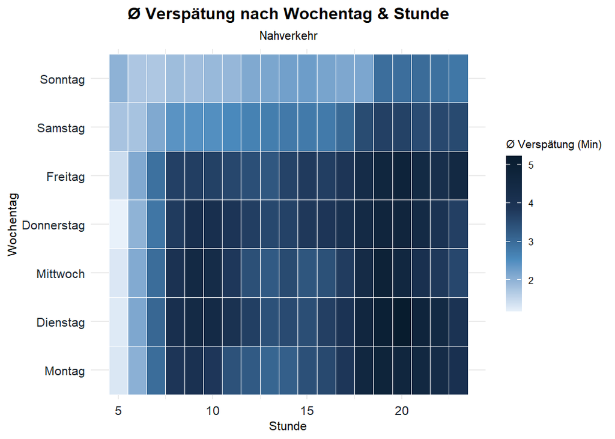

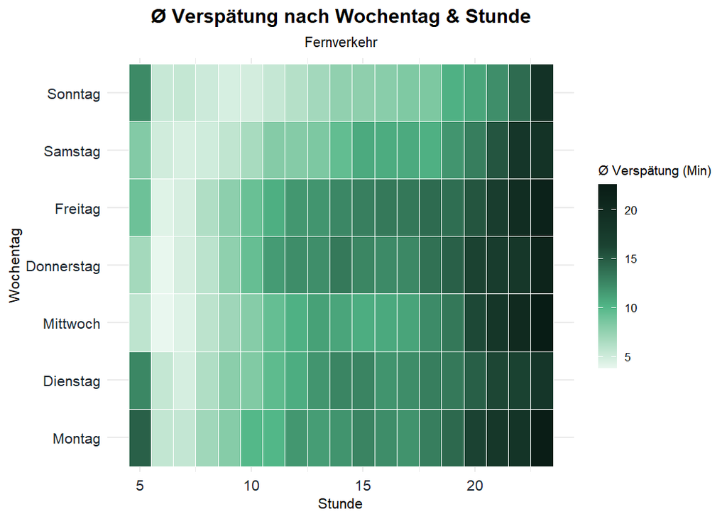

**Beschreibung der Grafiken**

Die beiden Grafiken zeigen die durchschnittlichen Verspätungen im Bahnverkehr nach Wochentag und Uhrzeit, getrennt nach Nahverkehr (Blautöne) und Fernverkehr (Grüntöne). Auf der x-Achse sind die Stunden des Tages von 5 bis 23 Uhr dargestellt, auf der y-Achse die einzelnen Wochentage. Je dunkler die jeweilige Farbskala, desto höher ist die durchschnittliche Verspätung in Minuten.

Im Nahverkehr ist erkennbar, dass in den frühen Morgenstunden nur geringe Verspätungen auftreten. Ab etwa 8 Uhr nehmen die Verspätungen an Werktagen deutlich zu und bleiben bis ungefähr 10 Uhr auf einem erhöhten Niveau. Auch zur Mittagszeit sind Verspätungen vorhanden, wenn auch etwas moderater. Ein weiterer deutlicher Anstieg zeigt sich am Abend, insbesondere zwischen etwa 18 und 20 Uhr. An Wochenenden (Samstag und Sonntag) sind die Farben insgesamt deutlich heller, was auf geringere durchschnittliche Verspätungen hinweist.

**Interpretation der Ergebnisse**

Die Grafiken verdeutlichen, dass sich Verspätungen zeitlich und nach Verkehrsart deutlich unterscheiden. Im Nahverkehr konzentrieren sich die höchsten Verspätungen auf die klassischen Pendelzeiten am Morgen und am Abend. Dies deutet darauf hin, dass hohe Nachfrage, viele Ein- und Ausstiege sowie eine dichtere Zugfolge in diesen Zeitfenstern zu Störungen im Betriebsablauf führen können.

Im Fernverkehr hingegen bauen sich Verspätungen über den Tag hinweg zunehmend auf. Einmal entstandene Verspätungen wirken sich offenbar auf nachfolgende Verbindungen aus und können sich bis in die späten Abendstunden fortsetzen. Da Fernverkehrszüge längere Strecken zurücklegen und stärker voneinander abhängen, ist eine vollständige Aufholung von Verspätungen im Tagesverlauf schwieriger.

**Hauptverspätungszeiten und Unterschiede zwischen Werktagen und Wochenende**

Im Nahverkehr treten die höchsten Verspätungen an Werktagen vor allem zwischen 8 und 10 Uhr sowie zwischen 18 und 20 Uhr auf. Diese Zeitfenster entsprechen den Hauptpendelzeiten. Am Wochenende sind die Verspätungen im Nahverkehr insgesamt deutlich geringer, da der Berufsverkehr weitgehend entfällt.

**Unterschiede zwischen Nah- und Fernverkehr**

Ein zentraler Unterschied liegt im zeitlichen Verlauf der Verspätungen. Während sich Verspätungen im Nahverkehr vor allem zu bestimmten Tageszeiten bündeln, steigen sie im Fernverkehr über den Tag hinweg kontinuierlich an. Zudem sind die absoluten Verspätungen im Fernverkehr insgesamt höher als im Nahverkehr, insbesondere in den Abendstunden.

**Bedeutung für Pendler**

Für Pendler, die überwiegend den Nahverkehr nutzen, sind die Ergebnisse besonders relevant. Gerade zu den Zeiten, in denen viele Menschen zur Arbeit fahren oder nach Hause pendeln, sind die Verspätungen am höchsten. Dies kann zu Zeitverlusten, verpassten Anschlüssen und einer geringeren Planbarkeit des Alltags führen. Die Grafiken zeigen somit, dass Verspätungen insbesondere für Berufspendler eine spürbare Belastung darstellen und vor allem in den Hauptverkehrszeiten auftreten.

## Von der Zeit zum Ort: Wo entstehen die Verspätungen?

In Aufgabe 7 haben Sie analysiert, **wann** die Verspätungen auftreten, nämlich vor allem zu den Hauptverkehrszeiten. Aber die nächste wichtige Frage ist: **Wo** entstehen diese Verspätungen?

Aggregierte Statistiken wie Durchschnittswerte über ganz Deutschland verbergen oft große regionale Unterschiede. Vielleicht gibt es einzelne “Problembahnhöfe”, die den Durchschnitt nach oben ziehen? Oder sind die Verspätungen gleichmäßig über das Netz verteilt? Diese Frage ist wichtig, weil sie unterschiedliche Lösungsansätze impliziert: Bei wenigen Problembahnhöfen könnte die Bahn gezielt investieren, bei flächendeckenden Problemen bräuchten Sie systemische Lösungen.

8. Identifizieren Sie die **10 unpünktlichsten Bahnhöfe** in Deutschland (mit mindestens 1.000 Halten im Monat). Nutzen Sie für diese Analyse den Datensatz `bahn`.

Erstellen Sie ein Balkendiagramm, das die durchschnittliche Verspätung dieser Bahnhöfe zeigt. Beschriften Sie die Balken mit den Verspätungswerten.

Beschreiben und interpretieren Sie ihre Grafik.

- Sehen Sie ein geografisches Muster?
- Handelt es sich um große Knotenbahnhöfe oder eher um kleinere Stationen?

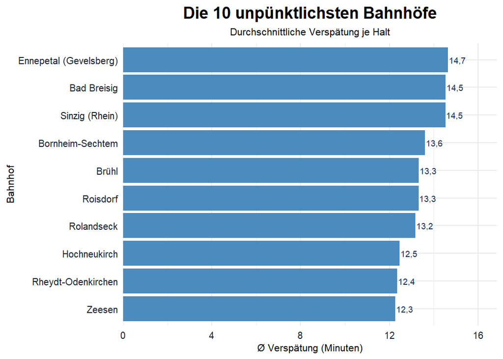

**Beschreibung der Grafik**

Die Grafik zeigt die zehn unpünktlichsten Bahnhöfe in Deutschland, gemessen an der durchschnittlichen Verspätung je Halt. Auf der x-Achse ist die durchschnittliche Verspätung in Minuten dargestellt, während die y-Achse die einzelnen Bahnhöfe auflistet. Die Werte sind absteigend sortiert, wobei Ennepetal mit einer durchschnittlichen Verspätung von 14,7 Minuten das Maximum darstellt. Demgegenüber ist der zehnt höchste Bahnhof Zeesen mit 12,3 Minuten. Alle Werte liegen dabei relativ nahe beieinander und drehen sich um einen Mittelwert von ca. 13,4 Minuten.

**Interpretation der Grafik**

Auffällig ist, dass es kein großer und bekannter Bahnhof in die Liste geschafft hat. Stattdessen handelt es sich überwiegend um kleine bis mittelgroße Bahnhöfe und nicht um große Knotenbahnhöfe. Dabei lässt sich ein deutliches geografisches Muster erkennen: Viele der aufgeführten Bahnhöfe liegen in Westdeutschland, insbesondere in Nordrhein-Westfalen und angrenzenden Regionen, und bilden dort ein stark zentriertes Netz.

Die Ursachen für diese räumliche Konzentration sind vielfältig. Ein wesentlicher Grund für die hohen Verspätungszahlen liegt in der besonderen Bedeutung der linken Rheinstrecke, die als zentrale Nord-Süd-Achse zwischen Köln und Mainz fungiert (Wikipedia 2026). Diese Strecke wird von einem hohen Aufkommen an Fern-, Nah- und Güterverkehr genutzt und gilt seit Jahren als stark ausgelastet (Merkurist 2023).

Nahezu alle Züge, die aus südlicher Richtung nach Köln verkehren, nutzen diesen Streckenabschnitt, wodurch es regelmäßig zu Kapazitätsengpässen kommt. Laut Deutschlandfunk gilt eine hohe Netzauslastung als eine der Hauptursachen für Verspätungen im deutschen Schienenverkehr, da bereits kleine Störungen zu erheblichen Folgeverspätungen führen können (Deutschlandfunk 2023). Dieser Effekt zeigt sich besonders auf der linken Rheinstrecke, da Verspätungen einzelner Züge schnell auf nachfolgende Verbindungen übergreifen.

Zusätzlich verschärft der ausgeprägte Mischverkehr die Situation. Auf derselben Infrastruktur verkehren sowohl langsame Regionalzüge als auch schnelle Fernverkehrszüge, was Überholungen erschwert und den Fahrplan anfällig für Störungen macht (Merkurist 2023). Darüber hinaus ist die Strecke aufgrund ihrer hohen verkehrlichen Bedeutung regelmäßig von Bauarbeiten betroffen, die die Kapazität weiter einschränken und den Dominoeffekt von Verspätungen verstärken können (Deutschlandfunk 2023).

# Wo treffen viele Pendler auf eine unpünktliche Bahn?

Bisher haben Sie Pendler- und Bahndaten getrennt betrachtet. Aber die spannende Frage ist: **Wo kommen beide Probleme zusammen?** Eine Stadt mit vielen Pendlern und einer unpünktlichen Bahn hat ein größeres Problem als eine Stadt mit wenigen Pendlern und einer unpünktlichen Bahn.

Um diese Frage zu beantworten, müssen Sie die Datensätze verknüpfen. Das Problem: Die Bahndaten sind auf Bahnhofsebene, die Pendlerdaten auf Kreisebene. Sie benötigen ein **Mapping**, das Bahnhöfe den entsprechenden Kreisen zuordnet.

9. In dieser Aufgabe verknüpfen Sie die Bahn- und Pendlerdaten, um Städte mit Handlungsbedarf zu identifizieren. Nutzen Sie für ihre Analysen die Datensätze: `bahn`, `pendler` und `bahnhof_mapping`.

Das Mapping ordnet Bahnhöfe ihrem Landkreis zu (via AGS = Amtlicher Gemeindeschlüssel). Ihr Ziel: Identifizieren Sie Städte, in denen **viele Pendler auf eine unpünktliche Bahn** treffen.

- Berechnen Sie für jeden Bahnhof die durchschnittliche Verspätung und die Anzahl der Halte.
- **Aggregation auf Kreisebene:** Berechnen Sie für jeden Kreis die **gewichtete durchschnittliche Verspätung**. Gewichten Sie nach der Anzahl der Halte (ein Bahnhof mit 10.000 Halten zählt mehr als einer mit 100).
- Verknüpfen Sie das Ergebnis mit den Pendlerdaten mittels `left_join()` über die Variable `ags`.
- **Problem-Score berechnen:** Kombinieren Sie beide Dimensionen mit z-Standardisierung:

$$\text{Problem-Score} =
z(\text{Einpendler}) + z(\text{Verspätung})$$

Die z-Standardisierung macht die Werte vergleichbar: $z(x) = \frac{x - \bar{x}}{s_x}$, wobei $\bar{x}$ der Mittelwert und $s_x$ die Standardabweichung ist.

**Interpretation:** Ein hoher Problem-Score = Viele Pendler + hohe Verspätung = **Handlungsbedarf**.

Anschließend sollten Sie eine Tabelle der **Top 10 Städte** nach Problem-Score darstellen und diese kurz beschreiben.

**Top 10 Städte nach Problem-Score**

[output not shown]

**Beschreibung**

Die vorliegende Tabelle führt die Ergebnisse der Bahnanalyse und der Pendlerstatistik zusammen. Sie zeigt die Top 10 Kreise Deutschlands, sortiert nach dem berechneten “Problem-Score”. In den Spalten sind der Name des Kreises, die absolute Anzahl der Einpendler sowie die gewichtete durchschnittliche Verspätung in Minuten aufgeführt. Der Problem-Score in der letzten Spalte dient als Maßstab für den Handlungsbedarf: Er kombiniert die Belastung (Pendleranzahl) mit der Unzuverlässigkeit (Verspätung). Zur besseren Vergleichbarkeit wurden die unterschiedlichen Einheiten hierfür in ein einheitliches Punktesystem umgerechnet.

**Interpretation**

Aus analytischer Sicht zeigt die Tabelle eine klare Zweiteilung der Problemursachen. An der Spitze des Rankings stehen große Städte wie München, Köln und Düsseldorf. In diesen Fällen wird der hohe Problem-Score primär durch das enorme Pendleraufkommen getrieben. Selbst moderate Verspätungen führen hier zu einem hohen aggregierten Schaden, da sehr viele Personen betroffen sind.

Am unteren Ende der Top 10 stehen Städte wie Stuttgart und Bonn. Ihr Problem-Score fällt geringer aus, da entweder die Pendlerzahl oder die durchschnittliche Verspätung niedriger ist als bei den Spitzenreitern. Auffällig ist jedoch, dass einige dieser Städte trotz vergleichsweise kleiner Pendlerzahlen in die Top 10 gelangen. Hier sind es vor allem sehr hohe Verspätungen, die den Score nach oben treiben.

Insgesamt macht die Analyse deutlich, dass Handlungsbedarf aus zwei unterschiedlichen Mechanismen entsteht: aus sehr hohen Pendlerströmen in großen Metropolen sowie aus strukturell schlechter Pünktlichkeit in einzelnen Städten. Für die Priorisierung von Maßnahmen bedeutet dies, dass sowohl bevölkerungsstarke Ballungsräume als auch kleinere, aber besonders unzuverlässige Standorte gezielt adressiert werden sollten.

10. Erstellen Sie ein **Streudiagramm (Scatterplot)**, das die Beziehung zwischen Einpendlerzahl (x-Achse) und durchschnittlicher Verspätung (y-Achse) visualisiert.
- Zeichnen Sie horizontale und vertikale Linien beim jeweiligen Mittelwert ein, um **4 Quadranten** zu bilden
- Färben Sie die Punkte nach Quadrant
- Beschriften Sie die Städte mit den höchsten Problem-Scores
- Nutzen Sie eine logarithmische Skala für die x-Achse

Beschreiben und iInterpretieren Sie die vier Quadranten:

- **Oben rechts:** Viele Pendler + hohe Verspätung = ?
- **Oben links:** Wenige Pendler + hohe Verspätung = ?
- **Unten rechts:** Viele Pendler + niedrige Verspätung = ?
- **Unten links:** Wenige Pendler + niedrige Verspätung = ?

Beantworten Sie dabei auch folgende Fragen:

- Warum ist es sinnvoll die x-Achse zu logarithmieren?
- Welche Städte liegen im kritischen Quadranten?
- Was würden Sie der Deutschen Bahn empfehlen?

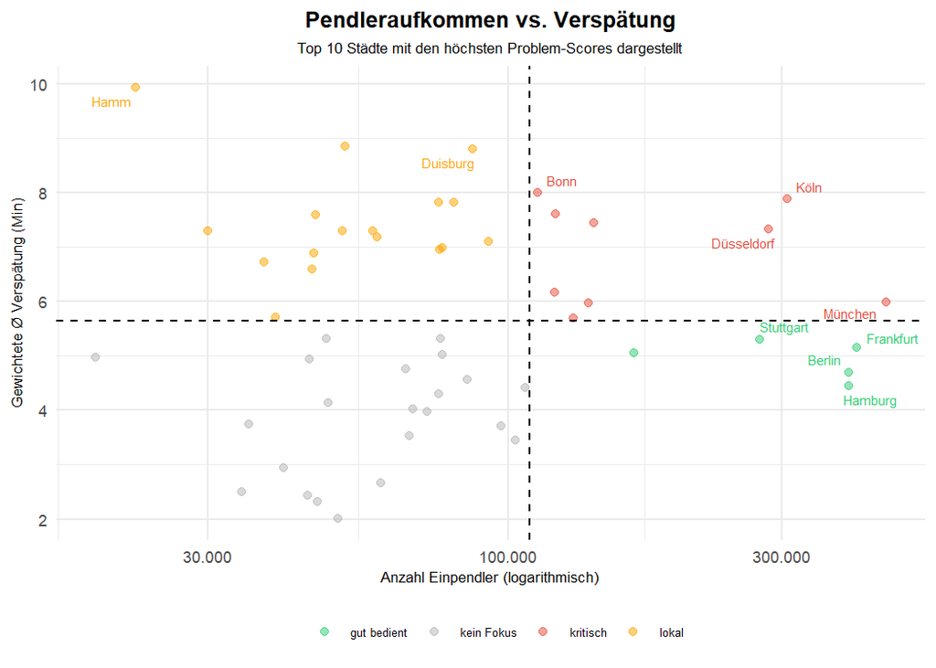

**Beschreibung des Streudiagramms**

Das Streudiagramm zeigt den Zusammenhang zwischen der Anzahl der Einpendler und der durchschnittlichen, gewichteten Verspätung im Bahnverkehr. Auf der x-Achse ist die Einpendlerzahl dargestellt, auf der y-Achse die durchschnittliche Verspätung in Minuten. Zur besseren Vergleichbarkeit sehr unterschiedlich großer Städte wurde die x-Achse logarithmisch skaliert. Zwei gestrichelte Linien markieren jeweils den Mittelwert der Einpendlerzahl sowie der Verspätung und teilen das Diagramm in vier Quadranten. Die Punkte sind entsprechend dieser Quadranten farblich codiert. Städte mit besonders hohen Problem-Scores sind zusätzlich beschriftet, um kritische Ballungsräume hervorzuheben.

**Interpretation der Quadranten**

Oben rechts: Viele Pendler und hohe Verspätung

Dieser Quadrant stellt den kritischsten Bereich dar. Hier liegen Städte wie München, Köln, Düsseldorf und Bonn. Diese Städte vereinen ein hohes Pendleraufkommen mit überdurchschnittlichen Verspätungen. Dadurch sind besonders viele Menschen von Unzuverlässigkeit im Bahnverkehr betroffen, was auf strukturelle Überlastung und Engpässe im Netz hindeutet.

Oben links: Wenige Pendler und hohe Verspätung

In diesem Quadranten befinden sich Städte mit vergleichsweise geringem Pendleraufkommen, aber dennoch hohen Verspätungen. Die Probleme sind hier eher lokal oder betrieblich bedingt und weniger auf hohe Nachfrage zurückzuführen. Der volkswirtschaftliche Schaden ist begrenzt, da relativ wenige Pendler betroffen sind.

Unten rechts: Viele Pendler und niedrige Verspätung

Dieser Bereich steht für große Städte mit hohem Verkehrsaufkommen, in denen der Bahnverkehr dennoch vergleichsweise zuverlässig funktioniert. Diese Städte können als Referenz für funktionierende Netz- und Betriebsstrukturen dienen.

Unten links: Wenige Pendler und niedrige Verspätung

Dieser Quadrant beschreibt Städte mit geringer Pendlerzahl und guter Pünktlichkeit. Hier besteht aktuell kein akuter Handlungsbedarf, da sowohl Belastung als auch Verspätungen niedrig sind.

**Begründung für die Logarithmierung der x-Achse**

Die logarithmische Skalierung der Einpendlerzahl ist sinnvoll, da sich die Städte stark in ihrer Größe unterscheiden. Ohne Logarithmierung würden große Städte mit mehreren hunderttausend Pendlern die Darstellung dominieren, während kleinere Städte kaum unterscheidbar wären. Durch die logarithmische Skala werden Ausreißer abgeschwächt und alle Städte bleiben vergleichbar sichtbar.

**Städte im kritischen Quadranten**

Im kritischen Quadranten mit hoher Pendlerzahl und hoher Verspätung liegen insbesondere Bonn, Köln, Düsseldorf und München. Diese Städte weisen die ungünstigste Kombination aus Verkehrsaufkommen und Pünktlichkeit auf und sollten daher prioritär betrachtet werden.

**Empfehlungen an die Deutsche Bahn**

Die Deutsche Bahn sollte Investitionen gezielt auf Städte im kritischen Quadranten konzentrieren. Maßnahmen wie der Ausbau von Knotenpunkten, zusätzliche Gleiskapazitäten und eine stabilere Betriebsführung können dort die größte Wirkung entfalten. Gleichzeitig können Städte mit hoher Nachfrage und guter Performance als Best-Practice-Beispiele dienen, um erfolgreiche Strategien auf andere Regionen zu übertragen.

# Der Vergleich – Auto vs. Bahn

Sie haben nun identifiziert, **wo** die Bahn Probleme hat: Städte im kritischen Quadranten (viele Pendler + hohe Verspätungen) brauchen dringend Verbesserungen. Aber bevor Sie Empfehlungen aussprechen können, müssen Sie eine zentrale Frage beantworten:

> **Lohnt sich die Bahn überhaupt – oder ist das Auto trotz Stau schneller?**

Denn selbst wenn die Bahn unpünktlich ist, könnte sie immer noch schneller sein als das Auto im Berufsverkehr. Umgekehrt: Eine pünktliche Bahn bringt wenig, wenn das Auto trotzdem schneller ist. Erst der **direkte Vergleich** zeigt uns, wo die Bahn wirklich konkurrenzfähig ist – und wo nicht.

## Methodische Herausforderungen

Für einen fairen Vergleich sollten Sie “Äpfel mit Äpfeln” vergleichen:

- Beim **Auto** muss der Stau berücksichtigt werden (nicht nur die theoretische Fahrzeit)
- Bei der **Bahn** muss die Verspätung berücksichtigt werden (nicht nur der Fahrplan)
- Beide Routen müssen **dieselben Start- und Endpunkte** haben

Für die Auto-Fahrtzeiten nutzen Sie **OSRM** (Open Source Routing Machine), das auf OpenStreetMap-Daten basiert. OSRM berechnet echte Straßenrouten, keine Luftlinien.

11. Erklären Sie in eigenen Worten:
- Warum ist OSRM-Routing für diesen Vergleich besser geeignet als eine einfache Berechnung nach der Formel `Distanz / Geschwindigkeit`?
- Welche Faktoren müssen zusätzlich berücksichtigt werden, um einen realistischen Vergleich zu ermöglichen? Denken Sie an:
  - Tageszeit
  - Parkplatzsuche
  - Fußweg zum Ziel
  - Wartezeit und Umsteigen bei der Bahn

**OSRM-Routing vs. einfache Fahrzeitberechnung**

Für den Vergleich der Reisezeiten von Auto und Bahn ist die Nutzung von `OSRM` deutlich besser geeignet als eine einfache Berechnung nach dem Prinzip „Distanz geteilt durch Geschwindigkeit“. Während eine solche Formel von idealisierten Annahmen ausgeht, bildet `OSRM` reale Verkehrsbedingungen ab. Das Routing basiert auf dem tatsächlichen Straßennetz aus OpenStreetMap und berücksichtigt unterschiedliche Straßentypen, Kreuzungen, Abbiegevorgänge sowie zulässige Höchstgeschwindigkeiten. Dadurch entstehen realitätsnahe Fahrzeiten, die insbesondere im urbanen Raum deutlich von theoretischen Durchschnittswerten abweichen können. Für eine faire Gegenüberstellung der Verkehrsmittel ist diese Genauigkeit notwendig, da sonst die Autonutzung systematisch zu positiv dargestellt würde.

**Zusätzliche Faktoren für einen realistischen Vergleich**

Ein realistischer Vergleich erfordert einen vollständigen “Tür-zu-Tür” Ansatz, der über die reine Fahrzeit hinausgeht. Beim Auto spielt die Tageszeit eine zentrale Rolle, da Stau vor allem in der Hauptverkehrszeit die tatsächliche Reisezeit stark verlängert. Hinzu kommt die Parkplatzsuche am Zielort, die insbesondere in Innenstädten einen erheblichen Zeitaufwand verursachen kann.

Auch bei der Bahn bestehen relevante Zusatzzeiten. Neben der eigentlichen Fahrt müssen Wartezeiten am Bahnsteig, Umsteigezeiten sowie Pufferzeiten eingeplant werden, um Anschlussverluste zu vermeiden. Zusätzlich entsteht meist ein Fußweg vom Bahnhof zum eigentlichen Ziel. Diese Elemente verlängern die effektive Reisezeit und sind für Pendler im Alltag entscheidend. Zwar folgt die Bahn grundsätzlich einem festen Fahrplan, allerdings machen die in Aufgabe 9 analysierten Verspätungen diesen theoretischen Zeitvorteil für viele Pendler wieder zunichte.

Ein wesentlicher qualitativer Unterschied liegt zudem in der Nutzbarkeit der Reisezeit. Während Autofahrer ihre volle Aufmerksamkeit dem Verkehr widmen müssen, ermöglicht die Bahnfahrt grundsätzlich das Arbeiten, Lesen oder Entspannen, was die wahrgenommene Belastung der Reisezeit reduzieren kann.

**Einordnung aus methodischer Sicht**

Aus methodischer Perspektive ist die Kombination aus OSRM-basierten Autofahrzeiten und empirischen Verspätungsdaten der Bahn ein zentraler Schritt für einen belastbaren Vergleich der Verkehrsmittel. Nur wenn beide Reiseformen entlang identischer Start- und Zielpunkte betrachtet und um realistische Zusatzzeiten ergänzt werden, lassen sich fundierte Aussagen über tatsächliche Zeitvorteile und Nachteile treffen. Zudem zeigt sich, dass reine Fahrzeitvergleiche nicht ausreichen, da auch Aspekte wie Zuverlässigkeit und Planbarkeit eine wesentliche Rolle für die wahrgenommene Qualität eines Verkehrsmittels spielen.

12. Für die Top 10 Einpendler-Städte wurden typische Pendlerstrecken definiert (z.B. Dachau $\rightarrow$ München, Neuss $\rightarrow$ Düsseldorf). Die OSRM-Ergebnisse liegen bereits vor. Nutzen Sie für ihre Analyse den Datensatz `fahrtzeit`.

Erstellen Sie:

- Eine **Tabelle** mit: Stadt, Strecke, Distanz (km), Auto-Fahrzeit (Hauptverkehrszeit), Bahn-Fahrzeit (real), Differenz
- Berechnen Sie die **jährliche Zeitersparnis** bei 220 Arbeitstagen und 2x täglichem Pendeln.

Interpretieren Sie ihre Tabelle:

- In wie vielen Fällen ist die Bahn schneller als das Auto?
- Wie viele Stunden pro Jahr kann ein Pendler maximal sparen?
- Gibt es Strecken, bei denen das Auto schneller ist? Woran könnte das liegen?

**Vergleich von Auto- und Bahnfahrzeiten auf typischen Pendlerstrecken**

| Stadt | Strecke | Distanz (km) | Auto-Fahrzeit HVZ (min) | Bahn-Fahrzeit real (min) | Differenz (min) | Zeitersparnis pro Jahr (h) |
| --- | --- | --- | --- | --- | --- | --- |
| München | Dachau → München | 19,10 | 40,20 | 26,08 | 14,12 | 103,53 |
| Frankfurt | Darmstadt → Frankfurt | 36,00 | 35,80 | 23,00 | 12,80 | 93,90 |
| Hamburg | Harburg → Hamburg | 14,20 | 24,00 | 16,27 | 7,73 | 56,71 |
| Berlin | Potsdam → Berlin | 34,20 | 49,30 | 29,58 | 19,72 | 144,63 |
| Köln | Leverkusen → Köln | 18,30 | 28,70 | 22,79 | 5,91 | 43,32 |
| Düsseldorf | Neuss → Düsseldorf | 12,10 | 27,10 | 17,10 | 10,00 | 73,35 |
| Stuttgart | Esslingen → Stuttgart | 14,00 | 27,20 | 20,17 | 7,03 | 51,55 |
| Nürnberg | Fürth → Nürnberg | 10,40 | 18,90 | 12,85 | 6,05 | 44,37 |
| Essen | Mülheim → Essen | 11,00 | 18,00 | 15,27 | 2,73 | 20,05 |
| Hannover | Celle → Hannover | 42,20 | 54,40 | 40,80 | 13,60 | 99,76 |
| Ulm | Neu-Ulm → Ulm | 3,70 | 8,10 | 8,89 | -0,79 | -5,77 |

**Interpretation der Tabelle**

Die Bahn ist auf den meisten Pendlerstrecken schneller als das Auto. Auf längeren Strecken in Großstädten wie Berlin, München, Frankfurt oder Hannover ergeben sich jährliche Zeitgewinne von 90 bis über 140 Stunden. Kurze Strecken zeigen nur geringe Vorteile für das Auto (<1 Minute pro Fahrt). Die Differenz der Fahrzeiten steigt mit der Distanz und der Verkehrsdichte, wodurch die Bahn auf stark frequentierten Pendlerstrecken besonders effizient ist.

**In wie vielen Fällen ist die Bahn schneller als das Auto?**

**Wie viele Stunden pro Jahr kann ein Pendler maximal sparen?**

**Gibt es Strecken, bei denen das Auto schneller ist? Woran könnte das liegen?**

Nur auf der sehr kurzen Strecke Neu-Ulm → Ulm ist das Auto minimal schneller (-0,79 Minuten). Das liegt an der direkten Straßenführung, wenigen Verkehrsbehinderungen und der kurzen Distanz von 3,7 km. Umsteigezeiten, Halte und Taktungen wirken sich hier stärker auf die Bahnfahrzeit aus.

**Vergleich von Auto- und Bahnfahrzeiten auf typischen Pendlerstrecken**

Auf längeren Pendlerstrecken (z. B. Potsdam → Berlin 20 Minuten, Dachau → München 14 Minuten) ist die Bahn deutlich schneller. Auf kurzen Strecken (<5 km) liegen die Zeitunterschiede bei unter einer Minute. Die jährlichen Einsparungen verdeutlichen, dass Bahnpendeln in der Mehrheit der Fälle schneller ist und die tägliche Pendelzeit erheblich reduziert.

**Empfehlung für Pendler und Deutsche Bahn**

Pendler sollten die Bahn auf mittleren und langen Strecken nutzen, insbesondere in Großstädten, um Zeit und Stress zu sparen. Die Deutsche Bahn kann durch Priorisierung stark frequentierter Strecken, bessere Taktung und kürzere Wartezeiten die Attraktivität steigern. Kurze Strecken könnten durch optimierte Nahverkehrsangebote effizienter gestaltet werden. Ein strategischer Fokus auf stark frequentierte Pendlerstrecken maximiert die jährliche Zeitersparnis.

13. Da Sie alle in Ulm studieren und eventuell aus dem Ulmer Umland einpendeln, sollten Sie die **5 wichtigsten Pendlerrouten nach Ulm** näher analysieren. Stellen Sie in einem **Dumbbell-Chart** (oder Lollipop-Chart) die Unterschiede zwischen Auto- und Bahnzeiten visuell dar. Nutzen Sie für ihre Analyse den Datensatz `ulm_routen`.

Die 5 wichtigsten Pendlerrouten nach Ulm sind:

- Neu-Ulm $\rightarrow$ Ulm
- Blaustein $\rightarrow$ Ulm
- Ehingen $\rightarrow$ Ulm
- Laupheim $\rightarrow$ Ulm
- Langenau $\rightarrow$ Ulm

Markieren Sie, welche Orte **keinen Bahnhof** haben.

Beschreiben und interpretieren Sie ihre Grafik. Welche Besonderheiten zeigen die ländlichen Strecken?

*Hinweis:* Nutzen Sie `geom_segment()` und `geom_point()` für ihr [Dumbbell-Chart](https://r-graph-gallery.com/web-dumbbell-chart-with-a-gap-column.html) oder [Lollipop-Chart](https://r-graph-gallery.com/303-lollipop-plot-with-2-values.html).

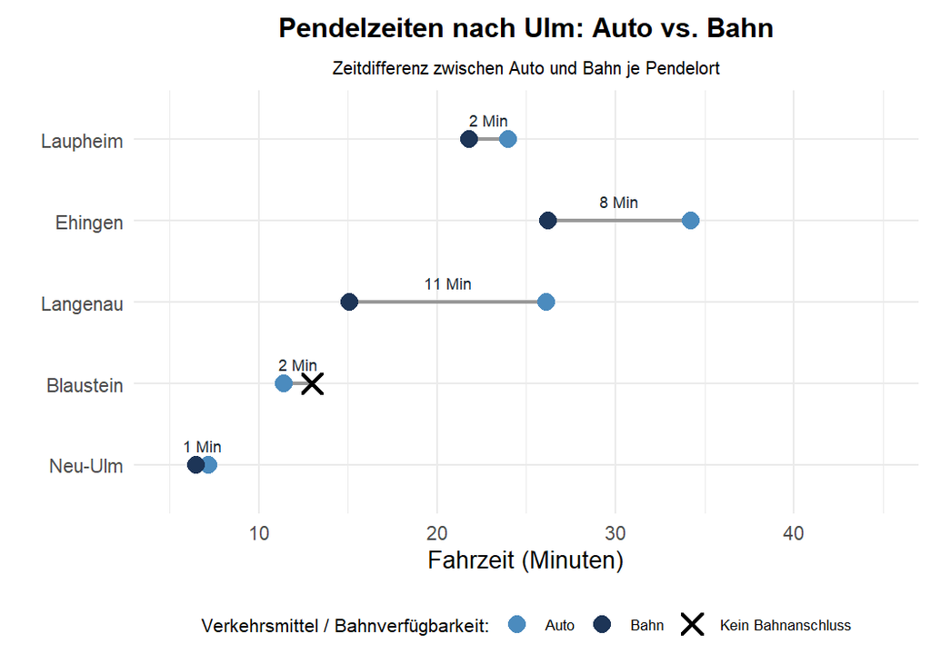

**Besonderheiten der ländlichen Strecken**

Die ländlichen Strecken weisen vor allem zwei charakteristische Merkmale auf. Zum einen können sich auf längeren Distanzen deutliche Zeitvorteile der Bahn ergeben, wodurch der Schienenverkehr grundsätzlich konkurrenzfähig gegenüber dem Auto ist. Zum anderen wird sichtbar, dass die Qualität und Dichte der Verkehrsanbindung im ländlichen Raum variiert. Insgesamt verdeutlicht die Grafik, dass eine gut ausgebaute und verlässliche Verkehrsinfrastruktur eine zentrale Voraussetzung für die Nutzung des öffentlichen Verkehrs im ländlichen Raum darstellt.

# Die volkswirtschaftlichen Kosten

Verspätungen kosten nicht nur Nerven, sie haben einen **realen volkswirtschaftlichen Preis**. Jede Minute, die ein Pendler im verspäteten Zug wartet, ist verlorene Arbeitszeit.

Um diese Kosten etwas besser zu quantifizieren sollten Sie sich den **Medianlohn** der jeweiligen Städte herunterladen und näher analysieren.

14. Berechnen Sie die volkswirtschaftlichen Kosten der Bahnverspätungen für die 11 Städte.

**Datensätze:**

- `staedte_basis` (aus Aufgabe 4) – enthält Einpendler, Medianlohn und Staudaten
- Ergebnis aus Aufgabe 9: die **gewichtete durchschnittliche Verspätung pro Stadt** (in Minuten)

Nutzen Sie die folgenden Annahmen:

**Annahmen:**

- 220 Arbeitstage pro Jahr
- 2 Fahrten pro Tag (Hin + Zurück)
- Ca. 8,4% der Pendler nutzen die Bahn (nationaler Durchschnitt laut [MiD 2023 Kurzbericht](https://www.mobilitaet-in-deutschland.de/pdf/MiD2023_Kurzbericht.pdf))

Berechnen Sie für jede Stadt:

- Anzahl der Bahnpendler (Einpendler × 8,4%)
- Verspätungsstunden pro Jahr (Verspätung × 220 × 2 / 60)
- Kosten pro Pendler (Verspätungsstunden × Stundenlohn)
- Gesamtkosten der Stadt

Erstellen Sie auf Basis ihrer Berechnung eine Tabelle, welche die Anzahl der Bahnpendler, die Verspätungsstunden pro Jahr, die Kosten pro Pendler und die Gesamtkosten der Stadt anschaulich darstellt.

Beschreiben und interpretieren Sie ihre Tabelle. Gehen Sie dabei auch auf die Gesamtkosten der 11 Städte ein. Erklären Sie außerdem, warum der **Medianlohn** für diese Berechnung besser geeignet ist als der Durchschnittslohn.

*Hinweis:* Für die Umrechnung auf Stundenlohn: Monatsentgelt / 160 (bei 40h/Woche).

**Volkswirtschaftliche Kosten der Bahnverspätungen (Status quo)**

| AGS | Stadt | Einpendler | Median-Stundenlohn (€) | Ø Verspätung (min) | Bahnpendler | Verspätung Std./Jahr | Kosten je Pendler (€) | Gesamtkosten Stadt (in Mio €) |
| --- | --- | --- | --- | --- | --- | --- | --- | --- |
| 09162 | München | 455.645 | 30,29 | 5,98 | 38.274 | 43,9 | 1.329 | 50,9 |
| 05315 | Köln | 306.905 | 27,49 | 7,89 | 25.780 | 57,9 | 1.591 | 41,0 |
| 06412 | Frankfurt am Main | 405.856 | 29,45 | 5,14 | 34.092 | 37,7 | 1.111 | 37,9 |
| 05111 | Düsseldorf | 284.696 | 28,27 | 7,33 | 23.914 | 53,8 | 1.520 | 36,3 |
| 02000 | Hamburg | 392.951 | 28,29 | 4,44 | 33.008 | 32,6 | 922 | 30,4 |
| 11000 | Berlin | 392.324 | 25,98 | 4,70 | 32.955 | 34,5 | 895 | 29,5 |
| 08111 | Stuttgart | 274.442 | 29,31 | 5,30 | 23.053 | 38,9 | 1.139 | 26,2 |
| 05113 | Essen | 141.296 | 24,92 | 7,45 | 11.869 | 54,6 | 1.361 | 16,2 |
| 09564 | Nürnberg | 165.496 | 26,46 | 5,05 | 13.902 | 37,1 | 981 | 13,6 |
| 03241 | Region Hannover | 137.924 | 25,98 | 5,97 | 11.586 | 43,8 | 1.138 | 13,2 |
| 08421 | Ulm | 68.341 | 26,95 | 4,02 | 5.741 | 29,5 | 795 | 4,6 |

**Beschreibung der Grafik/Tabelle**

Die Tabelle stellt die volkswirtschaftlichen Kosten von Bahnverspätungen im Status quo für elf ausgewählte Städte dar. In den Spalten werden zunächst strukturelle Merkmale wie der amtliche Gemeindeschlüssel (AGS), der Stadtname und die Anzahl der Einpendler ausgewiesen. Darauf folgen ökonomische Kenngrößen wie der Medianstundenlohn sowie verkehrliche Kennzahlen, darunter die durchschnittliche Verspätung pro Halt in Minuten und die daraus abgeleitete jährliche Verspätung pro Bahnpendler in Stunden. Zusätzlich zeigt die Tabelle die daraus resultierenden Kosten pro Pendler sowie die aggregierten Gesamtkosten pro Stadt in Millionen Euro. Die Zeilen repräsentieren die einzelnen Städte, wobei die Tabelle nach Höhe der Gesamtkosten sortiert ist. Auffällig ist, dass die Gesamtkosten stark zwischen den Städten variieren und von unter fünf Millionen Euro bis über fünfzig Millionen Euro reichen.

**Interpretation der Grafik/Tabelle**

Die Tabelle macht deutlich, dass Bahnverspätungen erhebliche volkswirtschaftliche Kosten verursachen, die sich zwischen den Städten deutlich unterscheiden. München weist mit rund 50,9 Millionen Euro die höchsten Gesamtkosten auf, gefolgt von Köln und Frankfurt am Main. Am unteren Ende der Skala liegen kleinere Städte wie Ulm mit vergleichsweise geringen Kosten. Entscheidend für die Höhe der Gesamtkosten ist dabei nicht allein die durchschnittliche Verspätung, sondern vor allem die Anzahl der Bahnpendler sowie das Lohnniveau. Städte mit vielen Einpendlern und hohen Medianlöhnen weisen selbst bei moderaten Verspätungswerten hohe Gesamtkosten auf. Umgekehrt können Städte mit relativ hohen Verspätungen, aber geringerer Pendlerzahl und niedrigerem Lohnniveau, niedrigere Gesamtkosten verursachen. Insgesamt summieren sich die Kosten der Bahnverspätungen über alle elf Städte zu einem erheblichen volkswirtschaftlichen Schaden, was die Relevanz von Pünktlichkeit im Schienenverkehr unterstreicht.

**Wie hoch sind die Gesamtkosten der Bahnverspätungen in den betrachteten Städten?**

Die Gesamtkosten variieren stark zwischen den Städten und reichen von wenigen Millionen Euro pro Jahr bis zu über 50 Millionen Euro. In der Summe ergeben sich für die elf betrachteten Städte sehr hohe volkswirtschaftliche Kosten, die deutlich machen, dass Bahnverspätungen kein Randphänomen, sondern ein relevantes wirtschaftliches Problem darstellen.

**Warum ist der Medianlohn für diese Berechnung besser geeignet als der Durchschnittslohn?**

Der Medianlohn ist robuster gegenüber Ausreißern als der Durchschnittslohn. Sehr hohe Einkommen einzelner Personen können den Durchschnitt stark verzerren, obwohl sie nicht repräsentativ für die Mehrheit der Pendler sind. Der Medianlohn beschreibt hingegen das typische Einkommen eines Pendlers, da genau die Hälfte der Beschäftigten mehr und die andere Hälfte weniger verdient. Für die Monetarisierung von Zeitverlusten durch Verspätungen ist der Median daher besser geeignet, weil er realistischere und stabilere Kostenschätzungen liefert und die tatsächliche Einkommensverteilung besser widerspiegelt.

15. Setzen Sie die Kosten der Bahn (aus Aufgabe 14) den Kosten des Autos gegenüber. Vergleichen Sie diese in einer Szenario-Analyse mittels eines gestapelten Balkendiagramms. Nutzen Sie für ihre Analysen den Datensatz `staedte_basis`.

Berechnen Sie zuerst die Kosten des Autostaus pro Stadt:

- Anzahl der Autopendler (Einpendler × 91,6%)
- Staukosten pro Autopendler (Staustunden × Stundenlohn)
- Gesamtkosten der Stadt durch Autostau

Führen Sie anschließend einen Szenario-Vergleich durch: Was passiert, wenn der Bahnanteil von 8,4% auf 20% steigt?

- Berechnen Sie die Gesamtkosten (Bahn + Auto) für beide Szenarien
- *Annahme:* Weniger Autos = weniger Stau (z.B. 20% weniger Stauzeit pro Autopendler)

Erstellen Sie ein gestapeltes Balkendiagramm nach Szenario. Beschreiben und intepretieren Sie ihre Grafik. Gehen Sie insbesondere auf die folgenden Fragen ein:

- Wie verteilen sich die Kosten zwischen Bahn und Auto im Status quo?
- Welches Verkehrsmittel verursacht den größeren volkswirtschaftlichen Schaden?
- Was ist die Nettoersparnis bei 20% Bahnanteil?

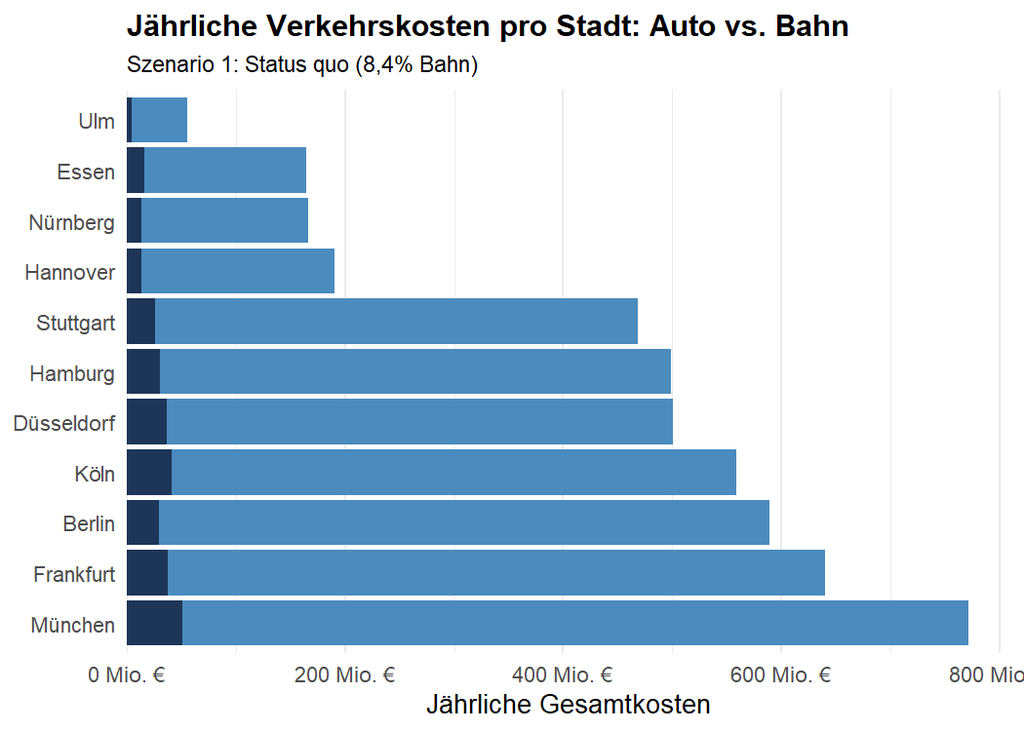

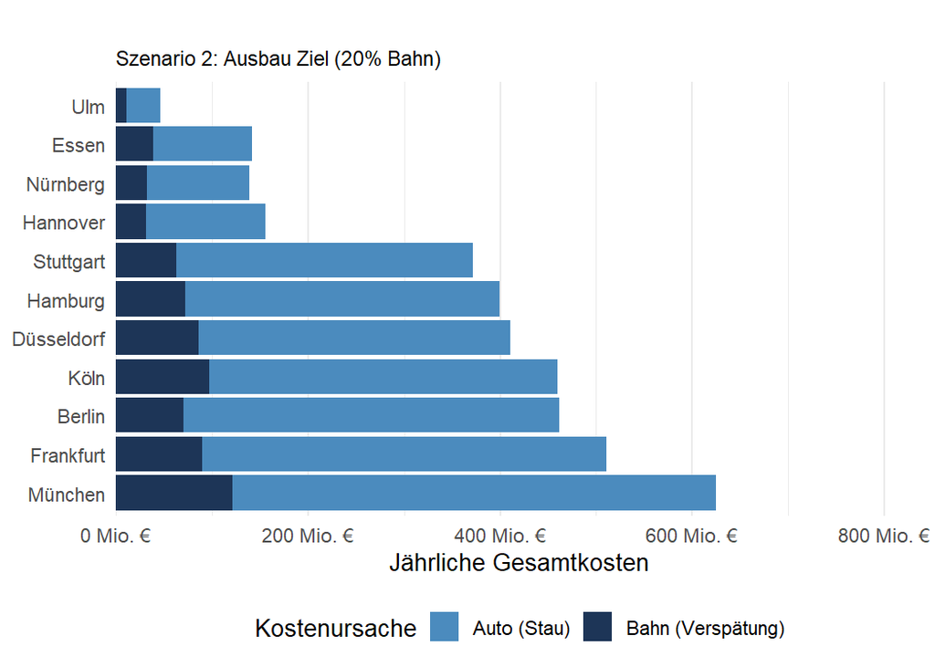

**Beschreibung der Grafik**

Die beiden Grafiken stellen die jährlichen volkswirtschaftlichen Verkehrskosten für ausgewählte Städte dar und vergleichen dabei die Kosten des Autoverkehrs mit denen des Bahnverkehrs. Auf der x-Achse sind die jährlichen Gesamtkosten in Millionen Euro abgetragen, auf der y-Achse die betrachteten Städte. Die Balken sind gestapelt und unterscheiden zwischen den Kosten durch Autostau und den Kosten durch Bahnverspätungen. Die obere Grafik zeigt den Status quo mit einem Bahnanteil von 8,4 Prozent, während die untere Grafik ein Ausbau-Szenario mit einem Bahnanteil von 20 Prozent darstellt. Auffällig ist, dass in beiden Szenarien die Autokosten den deutlich größten Anteil der Gesamtkosten ausmachen, während die Bahnkosten vergleichsweise gering bleiben. Gleichzeitig ist im zweiten Szenario ein deutlicher Rückgang der gesamten Balkenlängen zu erkennen.

**Interpretation der Grafik**

**Wie verteilen sich die Kosten zwischen Bahn und Auto im Status quo?**

Im Status quo entfällt der überwiegende Teil der volkswirtschaftlichen Verkehrskosten auf den Autoverkehr. Die Kosten durch Stau dominieren in allen betrachteten Städten deutlich, während die Kosten durch Bahnverspätungen nur einen vergleichsweise kleinen Anteil der Gesamtkosten ausmachen.

**Welches Verkehrsmittel verursacht den größeren volkswirtschaftlichen Schaden?**

Der Autoverkehr verursacht den deutlich größeren volkswirtschaftlichen Schaden. Die durch Stau entstehenden Zeitverluste summieren sich, insbesondere in großen Städten, zu sehr hohen Kosten und übersteigen die Kosten durch Bahnverspätungen um ein Vielfaches.

# Politikempfehlung – Ihre Synthese

Sie haben nun umfangreiche Analysen durchgeführt und viele Erkenntnisse über die Bahn gewonnen. Jetzt ist es Zeit, diese zu einer **kohärenten Empfehlung** zusammenzufügen.

**Szenario:** Sie sind Berater:in des Bundesministeriums für Digitales und Verkehr. Die Ministerin bittet Sie um eine evidenzbasierte Politikempfehlung zur Verbesserung des Pendlerverkehrs in Deutschland.

16. Formulieren Sie eine **Politikempfehlung** für das Bundesministerium für Digitales und Verkehr.

Schreiben Sie eine **Executive Summary (max. 5 Sätze)**. Fassen Sie hierbei die wichtigsten Erkenntnisse aus ihrem Projekt zusammen. Was ist die zentrale Botschaft?

Formulieren Sie 3 konkrete Empfehlungen. Jede muss enthalten:

- Ein konkretes **Ziel** (Was soll erreicht werden?)
- Eine messbare **Maßnahme** (Wie wird es umgesetzt?)
- Eine **Begründung mit Zahlen** aus Ihrer Analyse
- Nennen Sie **zwei Limitationen** Ihrer Datengrundlage
- Was würden Sie mit **zusätzlichen Daten** noch untersuchen?

**Executive Summary**

Unsere Analyse belegt, dass die Deutsche Bahn in den untersuchten Pendlerregionen bereits jetzt oft eine schnellere Alternative zum PKW darstellt, ihre Zuverlässigkeit jedoch das Kernproblem ist. Besonders in den identifizierten “Problem-Regionen” wie Frankfurt und Berlin führen Verspätungen zu massiven volkswirtschaftlichen Verlusten in Millionenhöhe. Ein Ausbau des Bahnanteils auf 20 % würde nicht nur den wirtschaftlichen Schaden durch Stau drastisch senken, sondern auch CO2-Einsparungen in der Größenordnung tausender Urlaubsflüge realisieren. Die zentrale Botschaft lautet: Nur durch eine gezielte Stabilisierung der hochbelasteten Knotenpunkte kann das ökologische und zeitliche Potenzial der Bahn voll ausgeschöpft werden.

**Konkrete Empfehlungen:**

Infrastruktur-Fokus auf systemkritische Knotenpunkte

Das primäre Ziel dieser Strategie ist eine maximale Reduktion des Zeitverlusts, die vor allem durch eine konsequente Stabilisierung der Pünktlichkeit erreicht wird. Um dies effizient umzusetzen, sieht die Maßnahme vor, gezielte Sanierungen und Digitalisierungsprojekte in den Kreisen durchzuführen, die den höchsten Problem-Score aufweisen – namentlich Berlin, Frankfurt am Main und München.

Schließung der “Last-Mile”-Lücke im ländlichen Raum

Um den Bahnanteil bei Pendlern aus dem Umland – wie beispielsweise der Region Ulm – nachhaltig zu erhöhen, ist eine gezielte Förderung von On-Demand-Shuttles und Express-Bussen notwendig. Diese Maßnahmen richten sich primär an Orte ohne direkten Bahnanschluss, mit dem Ziel, die gesamte „Tür-zu-Tür“-Reisezeit gegenüber dem Individualverkehr konkurrenzfähig zu halten.

Die Notwendigkeit dieser Strategie stützt sich auf unsere Analyse der Ulmer Routen (Aufgabe 13): Sie zeigt, dass Pendler in Orten ohne eigenen Bahnhof den Zeitvorteil der Bahn bisher nicht effektiv nutzen können (siehe Blaustein), da die Anbindung an den Schienenverkehr die entscheidende Schwachstelle darstellt.

Strategische Steigerung des Modal Split auf 20%

Das übergeordnete Ziel ist eine spürbare Entlastung der Umwelt sowie der städtischen Verkehrswege. Erreicht wird dies durch steuerliche Anreize für Arbeitgeber, die den Umstieg ihrer Mitarbeiter auf die Schiene finanziell oder strukturell unterstützen. Durch das daraus resultierende geringere PKW-Aufkommen lassen sich die Stauzeiten im Pendlerverkehr unmittelbar reduzieren.

Die wissenschaftliche Grundlage hierfür liefern die Analysen aus Aufgabe 15 und 19: Sie belegen, dass eine Steigerung des Bahnanteils auf 20 % allein im Raum Ulm CO2-Einsparungen im Wert von ungefähr 1750 Mallorca-Flügen ermöglicht. Gleichzeitig sorgt diese Verkehrsverlagerung dafür, dass die derzeitigen Millionenverluste signifikant gesenkt werden, was einen massiven volkswirtschaftlichen Mehrwert generiert. Allein in Hamburg könnten die jährlichen Verkehrskosten um 100 Millionen Euro gesenkt werden.

**Limitationen der Datengrundlage:**

Die Daten basieren ausschließlich auf dem November 2025, wodurch saisonale Effekte (Wetter, Urlaubszeit) nicht abgebildet werden.

Außerdem vernachlässigt die Nutzung des nationalen Durchschnitts von 8,4 % Bahnpendlern lokale Besonderheiten (z. B. höhere Quoten in Berlin vs. niedrigere in Ulm).

**Zusätzliche Untersuchungen:**

Mit Echtzeit-Staudaten (nicht nur Durchschnittswerten) ließe sich berechnen, an welchen spezifischen Wochentagen, Tageszeiten und Orten die Bahn die absolut beste Alternative zum Auto bietet.

# Zusatzaufgaben (optional)

Bisher haben Sie zwei Dimensionen betrachtet: **Zeit** (Bahn ist schneller) und **Geld** (Verspätungen kosten). Aber es gibt einen dritten, oft vergessenen Aspekt: die **Umwelt**.

Das Auto ist nicht nur langsamer und teurer; es ist auch ein Klimakiller. Ein durchschnittlicher PKW emittiert z.B. etwa **150 g CO2 pro Personenkilometer**.

17. Recherchieren Sie die CO2-Emissionsfaktoren und das Mobilitätsverhalten:
- Erstellen Sie eine kleine Tabelle in der Sie die CO2-Emissionen (in g/Personenkilometer) für folgende Verkehrsmittel auflisten:
  - PKW (Durchschnitt)
  - PKW (Elektro, deutscher Strommix)
  - ICE/IC (Fernverkehr)
  - RE/RB (Nahverkehr)
  - S-Bahn
- Berechnen Sie einen **gewichteten Durchschnitt** für die Bahn, wenn 70% der Pendler Nahverkehr und 30% Fernverkehr nutzen.
- Um wie viel Prozent sind die Bahn-Emissionen niedriger als beim Auto?

*Hinweis:* Nutzen Sie Daten vom Umweltbundesamt oder dem DB Umweltbericht.

**CO2-Emissionen pro Verkehrsmittel**

| Verkehrsmittel | CO2 Emission (g/pkm) |
| --- | --- |
| PKW (Durchschnitt) | 164 |
| PKW (Elektro, deutscher Strommix) | 70 |
| ICE/IC (Fernverkehr) | 26 |
| RE/RB (Nahverkehr) | 44 |
| S-Bahn | 42 |

**Beschreibung**

Die Datengrundlage bilden aktuelle Werte des Umweltbundesamtes (UBA), welche die Treibhausgas-Emissionen verschiedener Verkehrsmittel pro Personenkilometer gegenüberstellen (Umweltbundesamt 2025). Ein herkömmlicher PKW mit Verbrennungsmotor wird dabei mit 164 g/km geführt, während ein Elektroauto im deutschen Strommix bei 70 g/km liegt. Für die Bahn wurde ein gewichteter Emissionsfaktor herangezogen, der mit einem Mix aus 30 % Fernverkehr und 70 % Nahverkehr ein realistisches Szenario für Pendler abbildet. Auf Basis dieser Werte ergibt sich durch den Umstieg vom Auto auf die Schiene eine unmittelbare Reduktion der fahrtbezogenen Emissionen um 76,9 %.

**Interpretation**

Beim Blick auf diese Zahlen wird schnell deutlich, wie massiv die Wahl des Verkehrsmittels die persönliche Klimabilanz beeinflusst. Ein gewöhnlicher PKW verursacht im direkten Vergleich etwa das Vierfache der CO2-Emissionen eines durchschnittlichen Zugs. Selbst gegenüber dem Elektroauto hat die Bahn ökologisch klar die Nase vorn und spart pro Kilometer noch einmal rund die Hälfte der Treibhausgase ein. Wer sich für den Weg zur Arbeit für die Schiene statt für das eigene Auto entscheidet, nutzt damit den wohl effektivsten Hebel zur Reduktion des persönlichen CO2-Fußabdrucks. Es ist die wirkungsvollste Einzelmaßnahme im Pendlerverkehr, um den eigenen ökologischen Impact sofort und spürbar zu senken.

18. Die Studie **“Mobilität in Deutschland” (MiD 2023)** ist die wichtigste Datenquelle zum Mobilitätsverhalten in Deutschland. Sie ermöglicht einen Vergleich mit 2017 (vor Corona).

Lesen Sie den [MiD 2023 Kurzbericht](https://www.mobilitaet-in-deutschland.de/pdf/MiD2023_Kurzbericht.pdf) und beantworten Sie:

- **Modal Split:** Wie hat sich der Anteil des öffentlichen Verkehrs (ÖV) am Gesamtverkehr zwischen 2017 und 2023 verändert?
- **Homeoffice-Effekt:** Wie hat sich die durchschnittliche Tagesstrecke verändert? Was ist laut MiD der Hauptgrund für diese Veränderung?
- **Stadt vs. Land:** Welchen Anteil hat das Deutschlandticket in Metropolen vs. ländlichen Räumen? Was bedeutet das für die Ulm-Region?
- **Implikation für CO2:** Welche Schlussfolgerung ziehen Sie aus diesen Veränderungen für das CO2-Einsparpotenzial durch Bahnpendeln? (2-3 Sätze)

Modal Split:

Der Anteil des öffentlichen Verkehrs (ÖV) am Gesamtverkehr hat sich bei etwa 11 % der Wege stabilisiert. Während der Anteil in Metropolen und Großstädten deutlich zugenommen hat, stagniert er im ländlichen Raum weiterhin auf einem niedrigen Niveau.

Homeoffice-Effekt:

Die durchschnittliche Tagesstrecke pro Person ist leicht zurückgegangen. Der Hauptgrund dafür ist laut MiD die Abnahme der Wegeanzahl: Durch das Homeoffice fallen tägliche Arbeitswege komplett weg, was die Gesamtmobilität reduziert, auch wenn die verbleibenden Wege (z. B. für Erledigungen oder Freizeit) tendenziell länger geworden sind.

Stadt vs. Land:

Es zeigt sich ein deutliches Gefälle beim Deutschlandticket: In Metropolen nutzen es ca. 40 % der Haushalte, in sehr ländlichen Räumen hingegen nur ca. 15 %. Für die Ulm-Region bedeutet dies eine Zweiteilung: Während die Kernstadt Ulm als Zentrum massiv von der Vergünstigung profitiert, bleibt der finanzielle Anreiz für Pendler aus dem Umland ohne direkten Bahnhofsanschluss (siehe Aufgabe 13) wirkungslos, da es an einem konkurrenzfähigen Angebot fehlt.

Implikation für CO2:

Das größte CO2-Einsparpotenzial ergibt sich aus der Kombination von Wegevermeidung durch Homeoffice und der Verlagerung der verbleibenden Präsenztage auf die Schiene. Da Bahnpendeln pro Kilometer deutlich CO2 gegenüber dem Auto einspart, ist die Gewinnung von Pendlern für das Deutschlandticket – insbesondere in Städten wie Ulm – der zentrale Hebel für die lokale Klimabilanz.

19. Berechnen Sie die **CO2-Ersparnis** für die 11 analysierten Städte.

**Datensatz:** `co2_analyse` (aus Aufgabe 4) – enthält Streckenlängen, Einpendlerzahlen und vorberechnete Werte

**Annahmen:**

- 220 Arbeitstage pro Jahr
- 2 Fahrten pro Tag (Hin + Zurück)
- CO2-Auto: 150 g/km, CO2-Bahn: 47 g/km (gewichteter Durchschnitt)

Berechnen Sie für **jeden Umsteiger** (Auto $\rightarrow$ Bahn):

- Jährliche Kilometer
- CO2-Emissionen mit Auto (kg/Jahr)
- CO2-Emissionen mit Bahn (kg/Jahr)
- **Ersparnis** (kg/Jahr)

Nun sollten Sie eine Szenario Analyse ähnlich wie in Aufgabe 15 durchführen: Wenn sich der Bahnanteil von 8,4% auf 20% erhöht: wie viele Tonnen CO2 würden in den 11 Städten jährlich eingespart?

Visualisieren Sie die CO2-Ersparnis pro Stadt.

Stellen Sie die Ersparnis in Kontext, um die Ersparnis greifbarer zu machen, z.B. wie viele **Mallorca-Flüge** (hin + zurück, ~750 kg CO2) entspricht das?

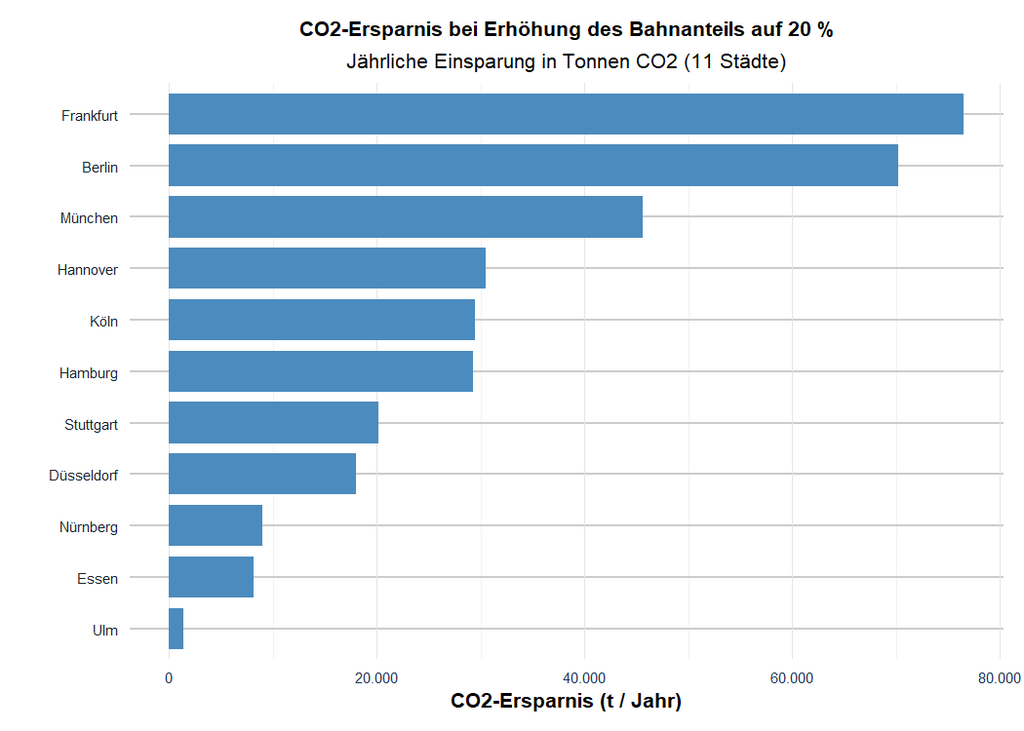

**CO2-Ersparnis pro Stadt** Äquivalent in Mallorca-Flügen bei Erhöhung des Bahnanteils auf 20 %

| Stadt | CO₂-Ersparnis (t/Jahr) | Ersparnis in Mallorca-Flügen |
| --- | --- | --- |
| Frankfurt | 76.513 | 102.017 |
| Berlin | 70.263 | 93.685 |
| München | 45.574 | 60.765 |
| Hannover | 30.480 | 40.640 |
| Köln | 29.411 | 39.215 |
| Hamburg | 29.220 | 38.960 |
| Stuttgart | 20.120 | 26.827 |
| Düsseldorf | 18.040 | 24.053 |
| Nürnberg | 9.013 | 12.018 |
| Essen | 8.139 | 10.852 |
| Ulm | 1.324 | 1.766 |

**Beschreibung**

Das Balkendiagramm veranschaulicht das jährliche CO2-Einsparpotenzial für elf ausgewählte Städte, basierend auf einer Steigerung des Bahnpendler-Anteils von aktuell 8,4 % auf 20 %. In die Berechnung fließen die spezifischen Einpendlerzahlen sowie die durchschnittlichen Wegstrecken bei 220 Arbeitstagen pro Jahr ein. In Städten wie Berlin und Frankfurt am Main werden dabei die höchsten absoluten Einsparwerte erzielt. Um die Mengen greifbarer zu machen, wird ein Flug nach Mallorca mit einer Emissionslast von etwa 750 kg CO2 als Vergleichswert herangezogen. Für eine Stadt wie Ulm weist die Grafik beispielsweise eine jährliche Ersparnis von rund 1.300 Tonnen CO2 aus.

**Interpretation**

Die Ergebnisse führen uns deutlich vor Augen, was für einen gewaltigen Hebel die lokale Verkehrspolitik für den Klimaschutz in der Hand hält. Besonders in den großen Metropolregionen wie Frankfurt und Berlin ist das Potenzial enorm, da hier durch die Masse an Pendlern die größten CO2-Mengen eingespart werden könnten. Aber auch in kleineren Standorten wie Ulm ist der Effekt beachtlich: Die dort eingesparten 1.300 Tonnen entsprechen dem CO2-Ausstoß von etwa 1.750 Hin- und Rückflügen nach Mallorca. Es zeigt sich zudem, dass Standorte mit weiten Pendlerdistanzen besonders stark von einer Verlagerung auf die Schiene profitieren. Der Ausbau der Bahninfrastruktur ist somit weit mehr als nur ein Zeitgewinn für die Reisenden – er ist ein entscheidender strategischer Faktor, um Klimaziele auf kommunaler Ebene überhaupt erreichen zu können.

# Anhang

## Anhang A: Beschreibung der bereitgestellten Datensätze

### 1. Bahnhof-Kreis-Mapping (`bahnhof_ags_mapping.csv`)

Dieses Mapping ist essenziell für die Verknüpfung von Bahn- und Pendlerdaten. Die Bahndaten sind auf **Bahnhofsebene** (z.B. “München Hbf”), die Pendlerdaten auf **Kreisebene** (z.B. “München, Landeshauptstadt”). Der AGS (Amtlicher Gemeindeschlüssel) ist der Schlüssel, der beide Welten verbindet.

**Wichtige Variablen:**

- `station_name`: Name des Bahnhofs
- `ags`: Amtlicher Gemeindeschlüssel (5-stellig für Kreise)
- `kreis_name`: Name des Landkreises/der kreisfreien Stadt

### 2. Fahrtzeit-Vergleich OSRM (`fahrtzeit_osrm_vergleich.csv`)

Für einen fairen Vergleich Auto vs. Bahn brauchen wir **realistische Fahrtzeiten**. OSRM (Open Source Routing Machine) berechnet echte Straßenrouten basierend auf OpenStreetMap – keine Luftlinien, sondern tatsächliche Straßenverbindungen mit Abbiegevorgängen, Geschwindigkeitsbegrenzungen und Straßentypen.

**Wichtige Variablen:**

- `stadt`: Zielstadt der Pendlerstrecke
- `strecke_name`: Beschreibung der Route (z.B. “Dachau $\rightarrow$ München”)
- `auto_distanz_km`: Fahrstrecke mit dem Auto in km
- `auto_hvz_min`: Fahrzeit Auto in der Hauptverkehrszeit (mit Staufaktor)
- `bahn_planzeit_min`: Fahrzeit laut Fahrplan
- `bahn_verspaetung_min`: Durchschnittliche Verspätung
- `bahn_real_min`: Realistische Bahnfahrzeit (Fahrplan + Verspätung)

**Wie wurde das Routing durchgeführt?**

1. **Koordinaten ermitteln:** Für jede Pendlerstrecke wurden Start- und Zielkoordinaten definiert (z.B. Stadtzentrum Dachau $\rightarrow$ München Hauptbahnhof).
2. **OSRM-API abfragen:** Über die öffentliche OSRM-Demo-API (`router.project-osrm.org`) wurden für jede Route Distanz und Fahrzeit abgefragt. Die API gibt die schnellste Route zurück, basierend auf dem aktuellen Straßennetz.
3. **Staufaktor anwenden:** Die OSRM-Basisfahrzeit entspricht einer Fahrt bei freiem Verkehr. Für die Hauptverkehrszeit (HVZ) wurde ein Staufaktor von 1,3-1,5 angewendet, basierend auf den INRIX-Daten der jeweiligen Stadt.
4. **Bahn-Daten ergänzen:** Die Bahnfahrzeiten stammen aus dem DB-Fahrplan, ergänzt um die durchschnittliche Verspätung aus unserer Analyse.

**Weiterführende Links:**

- [OSRM Projekt-Website](http://project-osrm.org/) – Dokumentation und Demo
- [OSRM API-Dokumentation](http://project-osrm.org/docs/v5.24.0/api/) – Technische Details zur API
- [OpenStreetMap](https://www.openstreetmap.org/) – Die Kartendaten, auf denen OSRM basiert
- R-Paket [`osrm`](https://cran.r-project.org/package=osrm) – Für eigene OSRM-Abfragen in R

### 3. Ulm-Pendlerrouten (`ulm_pendlerrouten.csv`)

Da Sie in Ulm studieren, analysieren wir die wichtigsten Pendlerrouten in die Stadt genauer. Dieser Datensatz enthält die 5 wichtigsten Einpendler-Gemeinden mit detaillierten Informationen zur Erreichbarkeit.

**Wichtige Variablen:**

- `start_ort`: Startgemeinde der Pendlerroute
- `ziel_ort`: Zielort (Ulm)
- `auto_dauer_min`: Fahrzeit mit dem Auto
- `auto_hvz_min`: Fahrzeit Auto in der Hauptverkehrszeit
- `bahn_fahrplan_min`: Bahnfahrzeit laut Fahrplan
- `bahn_real_min`: Realistische Bahnfahrzeit
- `hat_bahnhof`: TRUE/FALSE – hat der Startort einen Bahnanschluss?
- `pendler_geschaetzt`: Geschätzte Anzahl Pendler auf dieser Route

### 4. Entgeltstatistik (`ba_entgeltstatistik_2024.csv`)

Um die volkswirtschaftlichen Kosten von Verspätungen zu berechnen, brauchen wir **regionale Lohndaten**. Diese haben wir von der Bundesagentur für Arbeit heruntergeladen.

**Wichtige Variablen:**

- `kreis_name`: Name des Kreises/der Stadt
- `ags`: Amtlicher Gemeindeschlüssel
- `medianentgelt_brutto_monat`: Median-Bruttomonatsentgelt in Euro

**Quelle:** Bundesagentur für Arbeit, Entgeltstatistik 2024

# Quellenverzeichnis

#### Deutsche Bahn (2025)

Deutsche Bahn (2025):  
Pünktlichkeitswerte – Zahlen und Fakten.  
Online verfügbar unter: https://www.deutschebahn.com/de/konzern/konzernprofil/zahlen_fakten/puenktlichkeitswerte-6878476  
(Zugriff: 28.01.2026).

#### Deutschlandfunk (2023)

Deutschlandfunk (2023):  
Warum Züge in Deutschland so oft verspätet sind.  
Online verfügbar unter: https://www.deutschlandfunk.de/deutsche-bahn-verspaetung-zug-gruende-puenktlichkeit-100.html  
(Zugriff: 28.01.2026).

#### Merkurist (2023)

Merkurist (2023):  
Volle Züge, Verspätungen und Zugausfälle: Das sind die Gründe.  
Online verfügbar unter: https://merkurist.de/mainz/rb-26-zugausfaelle-und-verspaetungen-bei-der-mittelrheinbahn-das-sind-die-gruende_xGL  
(Zugriff: 28.01.2026).

#### Our World in Data (2025)

Our World in Data (2025):  
Labour productivity (GDP per hour worked) – Penn World Table.  
Datenbasis: Feenstra, R. C., Inklaar, R. & Timmer, M., *Penn World Table 11.0* (OECD-kompatible Produktivitätskennzahlen).  
Online verfügbar unter: https://ourworldindata.org/grapher/labor-productivity-per-hour-pennworldtable  
(Zugriff: 28.01.2026).

#### Umweltbundesamt (2025)

Umweltbundesamt (2025):  
Emissionsdaten – Verkehr.  
Online verfügbar unter: https://www.umweltbundesamt.de/themen/verkehr/emissionsdaten#verkehrsmittelvergleich-personenverkehr-grafik  
(Zugriff: 28.01.2026).

#### Wikipedia (2026)

Wikipedia (2026):  
Linke Rheinstrecke. In: Wikipedia – Die freie Enzyklopädie.  
Online verfügbar unter: https://de.wikipedia.org/wiki/Linke_Rheinstrecke  
(Zugriff: 28.01.2026).